# phase2cancer

2023-10-10

# 1. Problem

The problem is the accurate diagnosis of breast masses as malignant (cancerous) or benign (non- cancerous) using computed features from digitized images of fine needle aspirate (FNA). The features consist of radius, texture, perimeter, area, smoothness, compactness, concavity, concave.points, symmetry, and fractal_dimension of the mass,and there mean, worst, and standard error(SE).

The goal is to predict the nature of breast tumors based on the analyzed features, enabling medical professionals to make informed decisions regarding patient treatment and care.

Solving the problem of diagnosing breast cancer is important because it can lead to early detection, appropriate treatment plans, improved survival rates, and optimal allocation of healthcare resources.

# 2. Data Mining Task

The problem can be defined as a data mining binary classification task. The task involves training models and algorithms on the features of breast masses to predict whether a specific mass is malignant(M) or benign(B). The objective is to optimize the classification model’s accuracy and performance in differentiating between the two classes using the dataset as the training data. Data mining techniques such as feature selection, model training, and performance evaluation would be employed to solve this task efficiently.

Additionally, there is a potential clustering dimension to the task. Clustering involves grouping similar instances together based on inherent patterns or similarities in the data. In this case, clustering techniques could be applied to identify natural groupings or clusters within the dataset, which might reveal hidden structures or relationships among the breast masses. This could aid in gaining a deeper understanding of the underlying characteristics of different masses.

# 3. Data

We will go over a detailed description of the dataset used in this project. The dataset in focus is the Breast Cancer Wisconsin (Diagnostic) dataset, which plays a crucial role in achieving the goal of accurate breast cancer diagnosis and classification.

### The source of the dataset

https://www.kaggle.com/datasets/uciml/breast-cancer-wisconsin-data

### General information about the dataset

1- Number of attributes (variables, or columns): 32 (the last column (X) Contains only missing “NA” values, that why we didn’t count it, and it well be removed later on)

3- all variables are numeric, except id, and diagnosis.

4- The ID number is a nominal attribute

5- diagnosis is a binary (categoric, or factor) attribute and has two levels of values “B”,“M”.

6- Class name or labels: The diagnosis attribute represents the class labels, with “M” indicating malignant (cancerous) tumors and “B” indicating benign (non-cancerous) tumors.

### Attributes table

The attributes table present important information about the attributes associated with the dataset. This table serves as a reference guide, outlining the different attributes, their description, data type, and possible values. It aims to provide a comprehensive overview of the dataset, enabling us to understand and utilize the information effectively.

[output not shown]

# 4. Code

```r
library("tidyverse")
library("dplyr")
library("readr")
library("Hmisc")
library("outliers")
library("mlbench")
library("ggplot2")
library("lattice")
library("caret")
library("caTools")
library("corrplot")
library("reshape2")
```

```r
data <- read_csv("C:/Users/warif/OneDrive/Desktop/mining project data/data.csv")
```

[output not shown]

```r
head(data)
```

| id | diagnosis | radius_mean | texture_mean | perimeter_mean | area_mean | smoothness_mean | compactness_mean | concavity_mean | concave points_mean | symmetry_mean | fractal_dimension_mean | radius_se | texture_se | perimeter_se | area_se | smoothness_se | compactness_se | concavity_se | concave points_se | symmetry_se | fractal_dimension_se | radius_worst | texture_worst | perimeter_worst | area_worst | smoothness_worst | compactness_worst | concavity_worst | concave points_worst | … |
| --- | --- | --- | --- | --- | --- | --- | --- | --- | --- | --- | --- | --- | --- | --- | --- | --- | --- | --- | --- | --- | --- | --- | --- | --- | --- | --- | --- | --- | --- | --- |
| 842302 | M | 17.99 | 10.38 | 122.80 | 1001.0 | 0.11840 | 0.27760 | 0.3001 | 0.14710 | 0.2419 | 0.07871 | 1.0950 | 0.9053 | 8.589 | 153.40 | 0.006399 | 0.04904 | 0.05373 | 0.01587 | 0.03003 | 0.006193 | 25.38 | 17.33 | 184.60 | 2019.0 | 0.1622 | 0.6656 | 0.7119 | 0.2654 | … |
| 842517 | M | 20.57 | 17.77 | 132.90 | 1326.0 | 0.08474 | 0.07864 | 0.0869 | 0.07017 | 0.1812 | 0.05667 | 0.5435 | 0.7339 | 3.398 | 74.08 | 0.005225 | 0.01308 | 0.01860 | 0.01340 | 0.01389 | 0.003532 | 24.99 | 23.41 | 158.80 | 1956.0 | 0.1238 | 0.1866 | 0.2416 | 0.1860 | … |
| 84300903 | M | 19.69 | 21.25 | 130.00 | 1203.0 | 0.10960 | 0.15990 | 0.1974 | 0.12790 | 0.2069 | 0.05999 | 0.7456 | 0.7869 | 4.585 | 94.03 | 0.006150 | 0.04006 | 0.03832 | 0.02058 | 0.02250 | 0.004571 | 23.57 | 25.53 | 152.50 | 1709.0 | 0.1444 | 0.4245 | 0.4504 | 0.2430 | … |
| 84348301 | M | 11.42 | 20.38 | 77.58 | 386.1 | 0.14250 | 0.28390 | 0.2414 | 0.10520 | 0.2597 | 0.09744 | 0.4956 | 1.1560 | 3.445 | 27.23 | 0.009110 | 0.07458 | 0.05661 | 0.01867 | 0.05963 | 0.009208 | 14.91 | 26.50 | 98.87 | 567.7 | 0.2098 | 0.8663 | 0.6869 | 0.2575 | … |
| 84358402 | M | 20.29 | 14.34 | 135.10 | 1297.0 | 0.10030 | 0.13280 | 0.1980 | 0.10430 | 0.1809 | 0.05883 | 0.7572 | 0.7813 | 5.438 | 94.44 | 0.011490 | 0.02461 | 0.05688 | 0.01885 | 0.01756 | 0.005115 | 22.54 | 16.67 | 152.20 | 1575.0 | 0.1374 | 0.2050 | 0.4000 | 0.1625 | … |
| 843786 | M | 12.45 | 15.70 | 82.57 | 477.1 | 0.12780 | 0.17000 | 0.1578 | 0.08089 | 0.2087 | 0.07613 | 0.3345 | 0.8902 | 2.217 | 27.19 | 0.007510 | 0.03345 | 0.03672 | 0.01137 | 0.02165 | 0.005082 | 15.47 | 23.75 | 103.40 | 741.6 | 0.1791 | 0.5249 | 0.5355 | 0.1741 | … |

```r
nrow(data)
```

```
[1] 568
```

```r
ncol(data)
```

```
[1] 33
```

```r
dim(data)
```

```
[1] 568  33
```

```r
names(data)
```

```
 [1] "id"                      "diagnosis"               "radius_mean"             "texture_mean"
 [5] "perimeter_mean"          "area_mean"               "smoothness_mean"         "compactness_mean"
 [9] "concavity_mean"          "concave points_mean"     "symmetry_mean"           "fractal_dimension_mean"
[13] "radius_se"               "texture_se"              "perimeter_se"            "area_se"
[17] "smoothness_se"           "compactness_se"          "concavity_se"            "concave points_se"
[21] "symmetry_se"             "fractal_dimension_se"    "radius_worst"            "texture_worst"
[25] "perimeter_worst"         "area_worst"              "smoothness_worst"        "compactness_worst"
[29] "concavity_worst"         "concave points_worst"    "symmetry_worst"          "fractal_dimension_worst"
[33] "...33"
```

```r
str(data)
```

```
spc_tbl_ [568 × 33] (S3: spec_tbl_df/tbl_df/tbl/data.frame)
 $ id                     : num [1:568] 842302 842517 84300903 84348301 84358402 ...
 $ diagnosis              : chr [1:568] "M" "M" "M" "M" ...
 $ radius_mean            : num [1:568] 18 20.6 19.7 11.4 20.3 ...
 $ texture_mean           : num [1:568] 10.4 17.8 21.2 20.4 14.3 ...
 $ perimeter_mean         : num [1:568] 122.8 132.9 130 77.6 135.1 ...
 $ area_mean              : num [1:568] 1001 1326 1203 386 1297 ...
 $ smoothness_mean        : num [1:568] 0.1184 0.0847 0.1096 0.1425 0.1003 ...
 $ compactness_mean       : num [1:568] 0.2776 0.0786 0.1599 0.2839 0.1328 ...
 $ concavity_mean         : num [1:568] 0.3001 0.0869 0.1974 0.2414 0.198 ...
 $ concave points_mean    : num [1:568] 0.1471 0.0702 0.1279 0.1052 0.1043 ...
 $ symmetry_mean          : num [1:568] 0.242 0.181 0.207 0.26 0.181 ...
 $ fractal_dimension_mean : num [1:568] 0.0787 0.0567 0.06 0.0974 0.0588 ...
 $ radius_se              : num [1:568] 1.095 0.543 0.746 0.496 0.757 ...
 $ texture_se             : num [1:568] 0.905 0.734 0.787 1.156 0.781 ...
 $ perimeter_se           : num [1:568] 8.59 3.4 4.58 3.44 5.44 ...
 $ area_se                : num [1:568] 153.4 74.1 94 27.2 94.4 ...
 $ smoothness_se          : num [1:568] 0.0064 0.00522 0.00615 0.00911 0.01149 ...
 $ compactness_se         : num [1:568] 0.049 0.0131 0.0401 0.0746 0.0246 ...
 $ concavity_se           : num [1:568] 0.0537 0.0186 0.0383 0.0566 0.0569 ...
 $ concave points_se      : num [1:568] 0.0159 0.0134 0.0206 0.0187 0.0188 ...
 $ symmetry_se            : num [1:568] 0.03 0.0139 0.0225 0.0596 0.0176 ...
 $ fractal_dimension_se   : num [1:568] 0.00619 0.00353 0.00457 0.00921 0.00511 ...
 $ radius_worst           : num [1:568] 25.4 25 23.6 14.9 22.5 ...
 $ texture_worst          : num [1:568] 17.3 23.4 25.5 26.5 16.7 ...
 $ perimeter_worst        : num [1:568] 184.6 158.8 152.5 98.9 152.2 ...
 $ area_worst             : num [1:568] 2019 1956 1709 568 1575 ...
 $ smoothness_worst       : num [1:568] 0.162 0.124 0.144 0.21 0.137 ...
 $ compactness_worst      : num [1:568] 0.666 0.187 0.424 0.866 0.205 ...
 $ concavity_worst        : num [1:568] 0.712 0.242 0.45 0.687 0.4 ...
 $ concave points_worst   : num [1:568] 0.265 0.186 0.243 0.258 0.163 ...
 $ symmetry_worst         : num [1:568] 0.46 0.275 0.361 0.664 0.236 ...
 $ fractal_dimension_worst: num [1:568] 0.1189 0.089 0.0876 0.173 0.0768 ...
 $ ...33                  : logi [1:568] NA NA NA NA NA NA ...
 - attr(*, "spec")=
  .. cols(
  ..   id = col_double(),
  ..   diagnosis = col_character(),
  ..   radius_mean = col_double(),
  ..   texture_mean = col_double(),
```

[output cut: 16 more lines]

```
  ..   symmetry_se = col_double(),
  ..   fractal_dimension_se = col_double(),
  ..   radius_worst = col_double(),
  ..   texture_worst = col_double(),
  ..   perimeter_worst = col_double(),
  ..   area_worst = col_double(),
  ..   smoothness_worst = col_double(),
  ..   compactness_worst = col_double(),
  ..   concavity_worst = col_double(),
  ..   `concave points_worst` = col_double(),
  ..   symmetry_worst = col_double(),
  ..   fractal_dimension_worst = col_double(),
  ..   ...33 = col_logical()
  .. )
 - attr(*, "problems")=<externalptr>
```

```r
summary(data)
```

```
       id             diagnosis          radius_mean      texture_mean   perimeter_mean     area_mean
 Min.   :     8670   Length:568         Min.   : 6.981   Min.   : 9.71   Min.   : 43.79   Min.   : 143.5
 1st Qu.:   869222   Class :character   1st Qu.:11.707   1st Qu.:16.17   1st Qu.: 75.20   1st Qu.: 420.3
 Median :   906157   Mode  :character   Median :13.375   Median :18.84   Median : 86.29   Median : 551.4
 Mean   : 30425140                      Mean   :14.139   Mean   :19.28   Mean   : 92.05   Mean   : 655.7
 3rd Qu.:  8825022                      3rd Qu.:15.797   3rd Qu.:21.79   3rd Qu.:104.15   3rd Qu.: 784.1
 Max.   :911320502                      Max.   :28.110   Max.   :39.28   Max.   :188.50   Max.   :2501.0
 smoothness_mean   compactness_mean  concavity_mean    concave points_mean symmetry_mean    fractal_dimension_mean
 Min.   :0.06251   Min.   :0.01938   Min.   :0.00000   Min.   :0.00000     Min.   :0.1060   Min.   :0.04996
 1st Qu.:0.08640   1st Qu.:0.06517   1st Qu.:0.02958   1st Qu.:0.02035     1st Qu.:0.1620   1st Qu.:0.05770
 Median :0.09589   Median :0.09312   Median :0.06155   Median :0.03360     Median :0.1792   Median :0.06155
 Mean   :0.09644   Mean   :0.10445   Mean   :0.08896   Mean   :0.04901     Mean   :0.1812   Mean   :0.06280
 3rd Qu.:0.10533   3rd Qu.:0.13043   3rd Qu.:0.13100   3rd Qu.:0.07401     3rd Qu.:0.1957   3rd Qu.:0.06613
 Max.   :0.16340   Max.   :0.34540   Max.   :0.42680   Max.   :0.20120     Max.   :0.3040   Max.   :0.09744
   radius_se        texture_se      perimeter_se       area_se        smoothness_se      compactness_se
 Min.   :0.1115   Min.   :0.3602   Min.   : 0.757   Min.   :  6.802   Min.   :0.001713   Min.   :0.002252
 1st Qu.:0.2324   1st Qu.:0.8331   1st Qu.: 1.605   1st Qu.: 17.850   1st Qu.:0.005166   1st Qu.:0.013133
 Median :0.3240   Median :1.1080   Median : 2.285   Median : 24.565   Median :0.006374   Median :0.020460
 Mean   :0.4052   Mean   :1.2165   Mean   : 2.867   Mean   : 40.374   Mean   :0.007041   Mean   :0.025515
 3rd Qu.:0.4798   3rd Qu.:1.4743   3rd Qu.: 3.360   3rd Qu.: 45.237   3rd Qu.:0.008151   3rd Qu.:0.032455
 Max.   :2.8730   Max.   :4.8850   Max.   :21.980   Max.   :542.200   Max.   :0.031130   Max.   :0.135400
  concavity_se     concave points_se   symmetry_se       fractal_dimension_se  radius_worst   texture_worst
 Min.   :0.00000   Min.   :0.000000   Min.   :0.007882   Min.   :0.0008948    Min.   : 7.93   Min.   :12.02
 1st Qu.:0.01510   1st Qu.:0.007663   1st Qu.:0.015128   1st Qu.:0.0022445    1st Qu.:13.03   1st Qu.:21.07
 Median :0.02592   Median :0.010950   Median :0.018725   Median :0.0031955    Median :14.97   Median :25.41
 Mean   :0.03195   Mean   :0.011817   Mean   :0.020531   Mean   :0.0037967    Mean   :16.28   Mean   :25.67
 3rd Qu.:0.04212   3rd Qu.:0.014730   3rd Qu.:0.023398   3rd Qu.:0.0045585    3rd Qu.:18.80   3rd Qu.:29.68
 Max.   :0.39600   Max.   :0.052790   Max.   :0.078950   Max.   :0.0298400    Max.   :36.04   Max.   :49.54
 perimeter_worst    area_worst     smoothness_worst  compactness_worst concavity_worst  concave points_worst
 Min.   : 50.41   Min.   : 185.2   Min.   :0.07117   Min.   :0.02729   Min.   :0.0000   Min.   :0.00000
 1st Qu.: 84.15   1st Qu.: 515.7   1st Qu.:0.11660   1st Qu.:0.14758   1st Qu.:0.1159   1st Qu.:0.06497
 Median : 97.67   Median : 686.5   Median :0.13135   Median :0.21300   Median :0.2275   Median :0.10002
 Mean   :107.35   Mean   : 881.7   Mean   :0.13244   Mean   :0.25460   Mean   :0.2727   Mean   :0.11481
 3rd Qu.:125.53   3rd Qu.:1085.0   3rd Qu.:0.14602   3rd Qu.:0.33930   3rd Qu.:0.3835   3rd Qu.:0.16168
 Max.   :251.20   Max.   :4254.0   Max.   :0.22260   Max.   :1.05800   Max.   :1.2520   Max.   :0.29100
 symmetry_worst   fractal_dimension_worst  ...33
 Min.   :0.1565   Min.   :0.05504         Mode:logical
 1st Qu.:0.2504   1st Qu.:0.07147         NA's:568
 Median :0.2821   Median :0.08005
 Mean   :0.2901   Mean   :0.08397
 3rd Qu.:0.3180   3rd Qu.:0.09208
 Max.   :0.6638   Max.   :0.20750
```

```r
describe(data)
```

```
data

 33  Variables      568  Observations
--------------------------------------------------------------------------------------------------------------------
id
       n  missing distinct     Info     Mean      Gmd      .05      .10      .25      .50      .75      .90
     568        0      568        1 30425140 53928918    90265   853341   869223   906157  8825022 88144582
     .95
90426366

Value      0.0e+00 8.0e+07 9.0e+07 8.7e+08 8.8e+08 9.0e+08 9.1e+08
Frequency      487      49      21       2       2       2       5
Proportion   0.857   0.086   0.037   0.004   0.004   0.004   0.009

For the frequency table, variable is rounded to the nearest 10000000
--------------------------------------------------------------------------------------------------------------------
diagnosis
       n  missing distinct
     568        0        2

Value          B     M
Frequency    356   212
Proportion 0.627 0.373
--------------------------------------------------------------------------------------------------------------------
radius_mean
       n  missing distinct     Info     Mean      Gmd      .05      .10      .25      .50      .75      .90
     568        0      455        1    14.14    3.839    9.581   10.281   11.707   13.375   15.797   19.530
     .95
  20.576

lowest : 6.981 7.691 7.729 8.196 8.219, highest: 25.22 25.73 27.22 27.42 28.11
--------------------------------------------------------------------------------------------------------------------
texture_mean
       n  missing distinct     Info     Mean      Gmd      .05      .10      .25      .50      .75      .90
     568        0      478        1    19.28    4.785    13.09    14.08    16.17    18.84    21.79    24.99
     .95
   27.15

lowest : 9.71  10.38 10.72 10.82 10.89, highest: 31.12 32.47 33.56 33.81 39.28
--------------------------------------------------------------------------------------------------------------------
```

[output cut: 213 more lines]

```

lowest : 0.1565 0.1566 0.1603 0.1648 0.1652, highest: 0.5166 0.544  0.5558 0.5774 0.6638
--------------------------------------------------------------------------------------------------------------------
fractal_dimension_worst
       n  missing distinct     Info     Mean      Gmd      .05      .10      .25      .50      .75      .90
     568        0      534        1  0.08397  0.01885  0.06255  0.06579  0.07147  0.08005  0.09208  0.10633
     .95
 0.11955

lowest : 0.05504 0.05521 0.05525 0.05695 0.05737, highest: 0.1431  0.1446  0.1486  0.173   0.2075
--------------------------------------------------------------------------------------------------------------------

Variables with all observations missing:

[1] ...33
```

```r
data1 <- data
head(data1)
```

| id | diagnosis | radius_mean | texture_mean | perimeter_mean | area_mean | smoothness_mean | compactness_mean | concavity_mean | concave points_mean | symmetry_mean | fractal_dimension_mean | radius_se | texture_se | perimeter_se | area_se | smoothness_se | compactness_se | concavity_se | concave points_se | symmetry_se | fractal_dimension_se | radius_worst | texture_worst | perimeter_worst | area_worst | smoothness_worst | compactness_worst | concavity_worst | concave points_worst | … |
| --- | --- | --- | --- | --- | --- | --- | --- | --- | --- | --- | --- | --- | --- | --- | --- | --- | --- | --- | --- | --- | --- | --- | --- | --- | --- | --- | --- | --- | --- | --- |
| 842302 | M | 17.99 | 10.38 | 122.80 | 1001.0 | 0.11840 | 0.27760 | 0.3001 | 0.14710 | 0.2419 | 0.07871 | 1.0950 | 0.9053 | 8.589 | 153.40 | 0.006399 | 0.04904 | 0.05373 | 0.01587 | 0.03003 | 0.006193 | 25.38 | 17.33 | 184.60 | 2019.0 | 0.1622 | 0.6656 | 0.7119 | 0.2654 | … |
| 842517 | M | 20.57 | 17.77 | 132.90 | 1326.0 | 0.08474 | 0.07864 | 0.0869 | 0.07017 | 0.1812 | 0.05667 | 0.5435 | 0.7339 | 3.398 | 74.08 | 0.005225 | 0.01308 | 0.01860 | 0.01340 | 0.01389 | 0.003532 | 24.99 | 23.41 | 158.80 | 1956.0 | 0.1238 | 0.1866 | 0.2416 | 0.1860 | … |
| 84300903 | M | 19.69 | 21.25 | 130.00 | 1203.0 | 0.10960 | 0.15990 | 0.1974 | 0.12790 | 0.2069 | 0.05999 | 0.7456 | 0.7869 | 4.585 | 94.03 | 0.006150 | 0.04006 | 0.03832 | 0.02058 | 0.02250 | 0.004571 | 23.57 | 25.53 | 152.50 | 1709.0 | 0.1444 | 0.4245 | 0.4504 | 0.2430 | … |
| 84348301 | M | 11.42 | 20.38 | 77.58 | 386.1 | 0.14250 | 0.28390 | 0.2414 | 0.10520 | 0.2597 | 0.09744 | 0.4956 | 1.1560 | 3.445 | 27.23 | 0.009110 | 0.07458 | 0.05661 | 0.01867 | 0.05963 | 0.009208 | 14.91 | 26.50 | 98.87 | 567.7 | 0.2098 | 0.8663 | 0.6869 | 0.2575 | … |
| 84358402 | M | 20.29 | 14.34 | 135.10 | 1297.0 | 0.10030 | 0.13280 | 0.1980 | 0.10430 | 0.1809 | 0.05883 | 0.7572 | 0.7813 | 5.438 | 94.44 | 0.011490 | 0.02461 | 0.05688 | 0.01885 | 0.01756 | 0.005115 | 22.54 | 16.67 | 152.20 | 1575.0 | 0.1374 | 0.2050 | 0.4000 | 0.1625 | … |
| 843786 | M | 12.45 | 15.70 | 82.57 | 477.1 | 0.12780 | 0.17000 | 0.1578 | 0.08089 | 0.2087 | 0.07613 | 0.3345 | 0.8902 | 2.217 | 27.19 | 0.007510 | 0.03345 | 0.03672 | 0.01137 | 0.02165 | 0.005082 | 15.47 | 23.75 | 103.40 | 741.6 | 0.1791 | 0.5249 | 0.5355 | 0.1741 | … |

### Data reduction

We had an attribute in our dataset that was entirely made up of null values, thus we had to eliminate it under dimensionality reduction, attribute subset reduction, because it was an irrelevant attribute that contained no useful information.

All the other attributes were relevant to the class label where they describe the mass such as its radius, area or the texture, but the id attribute is not relevant to the class label since it does not describe the mass in any sense, so we had to perform dimensionality reduction that falls under attribute subset reduction, since the id didn’t contain any useful information.

```r
data1 <- subset(data1, select = -...33)
data1 <- subset(data1, select = -id)
data1 <- data1[, c(2:ncol(data1), 1)]
head(data1)
```

| radius_mean | texture_mean | perimeter_mean | area_mean | smoothness_mean | compactness_mean | concavity_mean | concave points_mean | symmetry_mean | fractal_dimension_mean | radius_se | texture_se | perimeter_se | area_se | smoothness_se | compactness_se | concavity_se | concave points_se | symmetry_se | fractal_dimension_se | radius_worst | texture_worst | perimeter_worst | area_worst | smoothness_worst | compactness_worst | concavity_worst | concave points_worst | symmetry_worst | fractal_dimension_worst | … |
| --- | --- | --- | --- | --- | --- | --- | --- | --- | --- | --- | --- | --- | --- | --- | --- | --- | --- | --- | --- | --- | --- | --- | --- | --- | --- | --- | --- | --- | --- | --- |
| 17.99 | 10.38 | 122.80 | 1001.0 | 0.11840 | 0.27760 | 0.3001 | 0.14710 | 0.2419 | 0.07871 | 1.0950 | 0.9053 | 8.589 | 153.40 | 0.006399 | 0.04904 | 0.05373 | 0.01587 | 0.03003 | 0.006193 | 25.38 | 17.33 | 184.60 | 2019.0 | 0.1622 | 0.6656 | 0.7119 | 0.2654 | 0.4601 | 0.11890 | … |
| 20.57 | 17.77 | 132.90 | 1326.0 | 0.08474 | 0.07864 | 0.0869 | 0.07017 | 0.1812 | 0.05667 | 0.5435 | 0.7339 | 3.398 | 74.08 | 0.005225 | 0.01308 | 0.01860 | 0.01340 | 0.01389 | 0.003532 | 24.99 | 23.41 | 158.80 | 1956.0 | 0.1238 | 0.1866 | 0.2416 | 0.1860 | 0.2750 | 0.08902 | … |
| 19.69 | 21.25 | 130.00 | 1203.0 | 0.10960 | 0.15990 | 0.1974 | 0.12790 | 0.2069 | 0.05999 | 0.7456 | 0.7869 | 4.585 | 94.03 | 0.006150 | 0.04006 | 0.03832 | 0.02058 | 0.02250 | 0.004571 | 23.57 | 25.53 | 152.50 | 1709.0 | 0.1444 | 0.4245 | 0.4504 | 0.2430 | 0.3613 | 0.08758 | … |
| 11.42 | 20.38 | 77.58 | 386.1 | 0.14250 | 0.28390 | 0.2414 | 0.10520 | 0.2597 | 0.09744 | 0.4956 | 1.1560 | 3.445 | 27.23 | 0.009110 | 0.07458 | 0.05661 | 0.01867 | 0.05963 | 0.009208 | 14.91 | 26.50 | 98.87 | 567.7 | 0.2098 | 0.8663 | 0.6869 | 0.2575 | 0.6638 | 0.17300 | … |
| 20.29 | 14.34 | 135.10 | 1297.0 | 0.10030 | 0.13280 | 0.1980 | 0.10430 | 0.1809 | 0.05883 | 0.7572 | 0.7813 | 5.438 | 94.44 | 0.011490 | 0.02461 | 0.05688 | 0.01885 | 0.01756 | 0.005115 | 22.54 | 16.67 | 152.20 | 1575.0 | 0.1374 | 0.2050 | 0.4000 | 0.1625 | 0.2364 | 0.07678 | … |
| 12.45 | 15.70 | 82.57 | 477.1 | 0.12780 | 0.17000 | 0.1578 | 0.08089 | 0.2087 | 0.07613 | 0.3345 | 0.8902 | 2.217 | 27.19 | 0.007510 | 0.03345 | 0.03672 | 0.01137 | 0.02165 | 0.005082 | 15.47 | 23.75 | 103.40 | 741.6 | 0.1791 | 0.5249 | 0.5355 | 0.1741 | 0.3985 | 0.12440 | … |

## Visualization

One of the main goals of visualizing the data here is to observe which features are most helpful in predicting malignant or benign cancer. The other is to see general trends that may aid us in model selection and hyper parameter selection.

### 1-pie chart

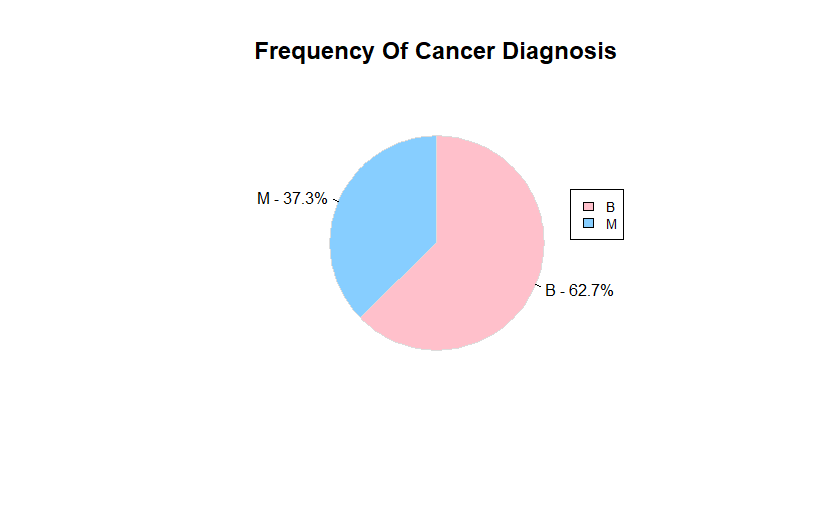

```r
diagnosis.table <- table(data$diagnosis)
colors <- terrain.colors(2)
# a pie chart for the diagnosis
diagnosis.prop.table <- prop.table(diagnosis.table)*100
diagnosis.prop.df <- as.data.frame(diagnosis.prop.table)
pielabels <- sprintf("%s - %3.1f%s", diagnosis.prop.df[,1], diagnosis.prop.table, "%")
colors = c ("pink", "skyblue1")
pie(diagnosis.prop.table,
    labels=pielabels,
    clockwise=TRUE,
    col=colors,
    border="gainsboro",
    radius=0.8,
    cex=0.8,
    main="Frequency Of Cancer Diagnosis")
legend(1, .4, legend=diagnosis.prop.df[,1], cex = 0.7,fill = colors)
```

```r
#Remove the first  column
data2 <- data[, -1]
#Remove the last column
data2 <- data2[,-32]
#Tidy the data
#bc_data$diagnosis <- as.factor(bc_data$diagnosis)
summary(data2)
```

```
  diagnosis          radius_mean      texture_mean   perimeter_mean     area_mean      smoothness_mean
 Length:568         Min.   : 6.981   Min.   : 9.71   Min.   : 43.79   Min.   : 143.5   Min.   :0.06251
 Class :character   1st Qu.:11.707   1st Qu.:16.17   1st Qu.: 75.20   1st Qu.: 420.3   1st Qu.:0.08640
 Mode  :character   Median :13.375   Median :18.84   Median : 86.29   Median : 551.4   Median :0.09589
                    Mean   :14.139   Mean   :19.28   Mean   : 92.05   Mean   : 655.7   Mean   :0.09644
                    3rd Qu.:15.797   3rd Qu.:21.79   3rd Qu.:104.15   3rd Qu.: 784.1   3rd Qu.:0.10533
                    Max.   :28.110   Max.   :39.28   Max.   :188.50   Max.   :2501.0   Max.   :0.16340
 compactness_mean  concavity_mean    concave points_mean symmetry_mean    fractal_dimension_mean   radius_se
 Min.   :0.01938   Min.   :0.00000   Min.   :0.00000     Min.   :0.1060   Min.   :0.04996        Min.   :0.1115
 1st Qu.:0.06517   1st Qu.:0.02958   1st Qu.:0.02035     1st Qu.:0.1620   1st Qu.:0.05770        1st Qu.:0.2324
 Median :0.09312   Median :0.06155   Median :0.03360     Median :0.1792   Median :0.06155        Median :0.3240
 Mean   :0.10445   Mean   :0.08896   Mean   :0.04901     Mean   :0.1812   Mean   :0.06280        Mean   :0.4052
 3rd Qu.:0.13043   3rd Qu.:0.13100   3rd Qu.:0.07401     3rd Qu.:0.1957   3rd Qu.:0.06613        3rd Qu.:0.4798
 Max.   :0.34540   Max.   :0.42680   Max.   :0.20120     Max.   :0.3040   Max.   :0.09744        Max.   :2.8730
   texture_se      perimeter_se       area_se        smoothness_se      compactness_se      concavity_se
 Min.   :0.3602   Min.   : 0.757   Min.   :  6.802   Min.   :0.001713   Min.   :0.002252   Min.   :0.00000
 1st Qu.:0.8331   1st Qu.: 1.605   1st Qu.: 17.850   1st Qu.:0.005166   1st Qu.:0.013133   1st Qu.:0.01510
 Median :1.1080   Median : 2.285   Median : 24.565   Median :0.006374   Median :0.020460   Median :0.02592
 Mean   :1.2165   Mean   : 2.867   Mean   : 40.374   Mean   :0.007041   Mean   :0.025515   Mean   :0.03195
 3rd Qu.:1.4743   3rd Qu.: 3.360   3rd Qu.: 45.237   3rd Qu.:0.008151   3rd Qu.:0.032455   3rd Qu.:0.04212
 Max.   :4.8850   Max.   :21.980   Max.   :542.200   Max.   :0.031130   Max.   :0.135400   Max.   :0.39600
 concave points_se   symmetry_se       fractal_dimension_se  radius_worst   texture_worst   perimeter_worst
 Min.   :0.000000   Min.   :0.007882   Min.   :0.0008948    Min.   : 7.93   Min.   :12.02   Min.   : 50.41
 1st Qu.:0.007663   1st Qu.:0.015128   1st Qu.:0.0022445    1st Qu.:13.03   1st Qu.:21.07   1st Qu.: 84.15
 Median :0.010950   Median :0.018725   Median :0.0031955    Median :14.97   Median :25.41   Median : 97.67
 Mean   :0.011817   Mean   :0.020531   Mean   :0.0037967    Mean   :16.28   Mean   :25.67   Mean   :107.35
 3rd Qu.:0.014730   3rd Qu.:0.023398   3rd Qu.:0.0045585    3rd Qu.:18.80   3rd Qu.:29.68   3rd Qu.:125.53
 Max.   :0.052790   Max.   :0.078950   Max.   :0.0298400    Max.   :36.04   Max.   :49.54   Max.   :251.20
   area_worst     smoothness_worst  compactness_worst concavity_worst  concave points_worst symmetry_worst
 Min.   : 185.2   Min.   :0.07117   Min.   :0.02729   Min.   :0.0000   Min.   :0.00000      Min.   :0.1565
 1st Qu.: 515.7   1st Qu.:0.11660   1st Qu.:0.14758   1st Qu.:0.1159   1st Qu.:0.06497      1st Qu.:0.2504
 Median : 686.5   Median :0.13135   Median :0.21300   Median :0.2275   Median :0.10002      Median :0.2821
 Mean   : 881.7   Mean   :0.13244   Mean   :0.25460   Mean   :0.2727   Mean   :0.11481      Mean   :0.2901
 3rd Qu.:1085.0   3rd Qu.:0.14602   3rd Qu.:0.33930   3rd Qu.:0.3835   3rd Qu.:0.16168      3rd Qu.:0.3180
 Max.   :4254.0   Max.   :0.22260   Max.   :1.05800   Max.   :1.2520   Max.   :0.29100      Max.   :0.6638
 fractal_dimension_worst
 Min.   :0.05504
 1st Qu.:0.07147
 Median :0.08005
 Mean   :0.08397
 3rd Qu.:0.09208
 Max.   :0.20750
```

```r
head(data2)
```

| diagnosis | radius_mean | texture_mean | perimeter_mean | area_mean | smoothness_mean | compactness_mean | concavity_mean | concave points_mean | symmetry_mean | fractal_dimension_mean | radius_se | texture_se | perimeter_se | area_se | smoothness_se | compactness_se | concavity_se | concave points_se | symmetry_se | fractal_dimension_se | radius_worst | texture_worst | perimeter_worst | area_worst | smoothness_worst | compactness_worst | concavity_worst | concave points_worst | symmetry_worst | … |
| --- | --- | --- | --- | --- | --- | --- | --- | --- | --- | --- | --- | --- | --- | --- | --- | --- | --- | --- | --- | --- | --- | --- | --- | --- | --- | --- | --- | --- | --- | --- |
| M | 17.99 | 10.38 | 122.80 | 1001.0 | 0.11840 | 0.27760 | 0.3001 | 0.14710 | 0.2419 | 0.07871 | 1.0950 | 0.9053 | 8.589 | 153.40 | 0.006399 | 0.04904 | 0.05373 | 0.01587 | 0.03003 | 0.006193 | 25.38 | 17.33 | 184.60 | 2019.0 | 0.1622 | 0.6656 | 0.7119 | 0.2654 | 0.4601 | … |
| M | 20.57 | 17.77 | 132.90 | 1326.0 | 0.08474 | 0.07864 | 0.0869 | 0.07017 | 0.1812 | 0.05667 | 0.5435 | 0.7339 | 3.398 | 74.08 | 0.005225 | 0.01308 | 0.01860 | 0.01340 | 0.01389 | 0.003532 | 24.99 | 23.41 | 158.80 | 1956.0 | 0.1238 | 0.1866 | 0.2416 | 0.1860 | 0.2750 | … |
| M | 19.69 | 21.25 | 130.00 | 1203.0 | 0.10960 | 0.15990 | 0.1974 | 0.12790 | 0.2069 | 0.05999 | 0.7456 | 0.7869 | 4.585 | 94.03 | 0.006150 | 0.04006 | 0.03832 | 0.02058 | 0.02250 | 0.004571 | 23.57 | 25.53 | 152.50 | 1709.0 | 0.1444 | 0.4245 | 0.4504 | 0.2430 | 0.3613 | … |
| M | 11.42 | 20.38 | 77.58 | 386.1 | 0.14250 | 0.28390 | 0.2414 | 0.10520 | 0.2597 | 0.09744 | 0.4956 | 1.1560 | 3.445 | 27.23 | 0.009110 | 0.07458 | 0.05661 | 0.01867 | 0.05963 | 0.009208 | 14.91 | 26.50 | 98.87 | 567.7 | 0.2098 | 0.8663 | 0.6869 | 0.2575 | 0.6638 | … |
| M | 20.29 | 14.34 | 135.10 | 1297.0 | 0.10030 | 0.13280 | 0.1980 | 0.10430 | 0.1809 | 0.05883 | 0.7572 | 0.7813 | 5.438 | 94.44 | 0.011490 | 0.02461 | 0.05688 | 0.01885 | 0.01756 | 0.005115 | 22.54 | 16.67 | 152.20 | 1575.0 | 0.1374 | 0.2050 | 0.4000 | 0.1625 | 0.2364 | … |
| M | 12.45 | 15.70 | 82.57 | 477.1 | 0.12780 | 0.17000 | 0.1578 | 0.08089 | 0.2087 | 0.07613 | 0.3345 | 0.8902 | 2.217 | 27.19 | 0.007510 | 0.03345 | 0.03672 | 0.01137 | 0.02165 | 0.005082 | 15.47 | 23.75 | 103.40 | 741.6 | 0.1791 | 0.5249 | 0.5355 | 0.1741 | 0.3985 | … |

### 2-correlations

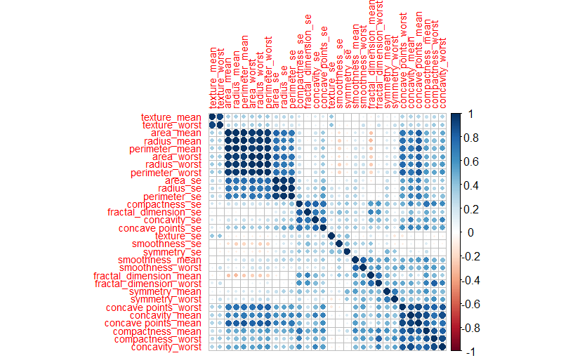

```r
#correlations
c <- cor(data2[,2:31])
corrplot(c, order = "hclust", tl.cex = 0.7)
```

## 3-covariance

```r
#covariance
cov(data2[, 2:31])
```

```
                          radius_mean  texture_mean perimeter_mean     area_mean smoothness_mean compactness_mean
radius_mean              1.236919e+01  4.975301e+00   8.510231e+01  1.221312e+03    7.977424e-03     9.368010e-02
texture_mean             4.975301e+00  1.848283e+01   3.490911e+01  4.912468e+02   -1.011624e-03     5.442489e-02
perimeter_mean           8.510231e+01  3.490911e+01   5.880537e+02  8.413770e+03    6.755770e-02     7.112491e-01
area_mean                1.221312e+03  4.912468e+02   8.413770e+03  1.236652e+05    8.411100e-01     9.230432e+00
smoothness_mean          7.977424e-03 -1.011624e-03   6.755770e-02  8.411100e-01    1.947699e-04     4.857460e-04
compactness_mean         9.368010e-02  5.442489e-02   7.112491e-01  9.230432e+00    4.857460e-04     2.787592e-03
concavity_mean           1.894640e-01  1.046989e-01   1.382769e+00  1.920452e+01    5.794142e-04     3.715166e-03
concave points_mean      1.121232e-01  4.951709e-02   7.999684e-01  1.122083e+01    2.989204e-04     1.700989e-03
symmetry_mean            1.404566e-02  8.642084e-03   1.203885e-01  1.443364e+00    2.136984e-04     8.716472e-04
fractal_dimension_mean  -7.811903e-03 -2.288540e-03  -4.524600e-02 -7.079805e-01    5.786523e-05     2.107603e-04
radius_se                6.646017e-01  3.297983e-01   4.668107e+00  7.160073e+01    1.176340e-03     7.296583e-03
texture_se              -1.871470e-01  9.163532e-01  -1.148607e+00 -1.271308e+01    5.479778e-04     1.371161e-03
perimeter_se             4.808444e+00  2.456719e+00   3.408833e+01  5.176555e+02    8.409834e-03     5.868120e-02
area_se                  1.179379e+02  5.112707e+01   8.232962e+02  1.281337e+04    1.563834e-01     1.094366e+00
smoothness_se           -2.357825e-03  8.418747e-05  -1.480274e-02 -1.764078e-01    1.407167e-05     2.150829e-05
compactness_se           1.278925e-02  1.500579e-02   1.076835e-01  1.324658e+00    7.886323e-05     6.976674e-04
concavity_se             2.033647e-02  1.893259e-02   1.651092e-01  2.183140e+00    1.031759e-04     9.077057e-04
concave points_se        8.061288e-03  4.465472e-03   6.024435e-02  8.000097e-01    3.218179e-05     2.083974e-04
symmetry_se             -2.974395e-03  2.674027e-04  -1.594145e-02 -2.060626e-01    2.386345e-05     1.012450e-04
fractal_dimension_se    -4.097096e-04  6.302523e-04  -4.345139e-04 -1.939842e-02    1.049477e-05     7.091231e-05
radius_worst             1.646623e+01  7.405394e+00   1.135286e+02  1.634705e+03    1.398606e-02     1.361530e-01
texture_worst            6.497238e+00  2.410914e+01   4.570315e+01  6.268507e+02    3.486180e-03     8.118962e-02
perimeter_worst          1.139490e+02  5.228339e+01   7.899822e+02  1.132152e+04    1.093622e-01     1.044100e+00
area_worst               1.884673e+03  8.484444e+02   1.300149e+04  1.920191e+05    1.610936e+00     1.528481e+01
smoothness_worst         9.164522e-03  8.017883e-03   8.037240e-02  9.587572e-01    2.557838e-04     6.786073e-04
compactness_worst        2.275181e-01  1.901025e-01   1.730778e+00  2.149580e+01    1.032656e-03     7.186655e-03
concavity_worst          3.850077e-01  2.731113e-01   2.842364e+00  3.747290e+01    1.257345e-03     8.980402e-03
concave points_worst     1.714075e-01  8.470121e-02   1.225101e+00  1.663529e+01    4.570223e-04     2.823966e-03
symmetry_worst           3.577533e-02  2.801888e-02   2.845696e-01  3.128831e+00    3.434686e-04     1.669721e-03
fractal_dimension_worst  2.980312e-04  9.402207e-03   2.137503e-02  1.244845e-02    1.260107e-04     6.553723e-04
                        concavity_mean concave points_mean symmetry_mean fractal_dimension_mean    radius_se
radius_mean               1.894640e-01        1.121232e-01  1.404566e-02          -7.811903e-03 6.646017e-01
texture_mean              1.046989e-01        4.951709e-02  8.642084e-03          -2.288540e-03 3.297983e-01
perimeter_mean            1.382769e+00        7.999684e-01  1.203885e-01          -4.524600e-02 4.668107e+00
area_mean                 1.920452e+01        1.122083e+01  1.443364e+00          -7.079805e-01 7.160073e+01
smoothness_mean           5.794142e-04        2.989204e-04  2.136984e-04           5.786523e-05 1.176340e-03
compactness_mean          3.715166e-03        1.700989e-03  8.716472e-04           2.107603e-04 7.296583e-03
concavity_mean            6.352525e-03        2.847542e-03  1.092593e-03           1.892722e-04 1.399175e-02
concave points_mean       2.847542e-03        1.504088e-03  4.909089e-04           4.546765e-05 7.522946e-03
```

[output cut: 131 more lines]

```
compactness_se                  5.655949e-04   3.083044e-04            1.909854e-04
concavity_se                    8.690687e-04   3.698595e-04            2.391802e-04
concave points_se               2.423883e-04   5.466730e-05            3.439887e-05
symmetry_se                    -1.529583e-05   1.995319e-04            1.182683e-05
fractal_dimension_se            3.729208e-05   1.821347e-05            2.828600e-05
radius_worst                    2.492264e-01   7.291282e-02            8.012550e-03
texture_worst                   1.465503e-01   8.879043e-02            2.447990e-02
perimeter_worst                 1.796511e+00   5.609849e-01            8.333025e-02
area_worst                      2.789769e+01   7.376858e+00            8.058225e-01
smoothness_worst                8.148531e-04   6.985958e-04            2.541310e-04
compactness_worst               8.261025e-03   5.990521e-03            2.302582e-03
concavity_worst                 1.169645e-02   6.883953e-03            2.584829e-03
concave points_worst            4.305155e-03   2.046631e-03            6.051249e-04
symmetry_worst                  2.046631e-03   3.834318e-03            6.019829e-04
fractal_dimension_worst         6.051249e-04   6.019829e-04            3.264600e-04
```

### 4-Boxplot

Comparing the raidus, area and concavity of benging malignant stage By constructing a box plot with the function ggplot()+geom_boxplot(), we notice malignant cells have higher radius, area and concavity mean than benign cell which is an information we can use later for predicting and training the data.

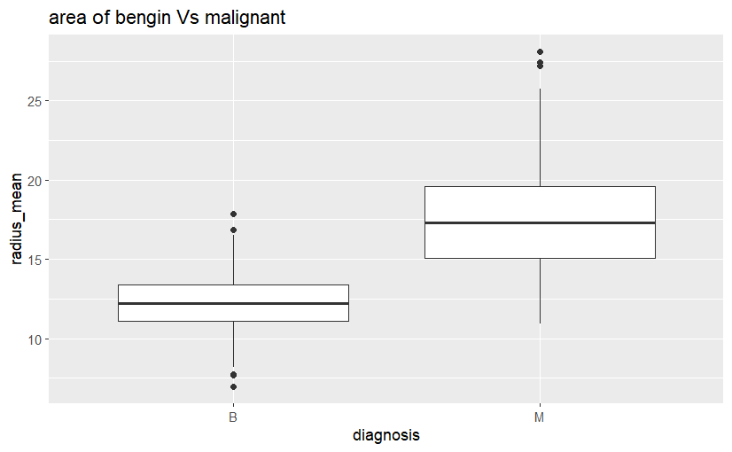

```r
# Comparing the raidus, area and concavity of benging malignant stage
ggplot(data2, aes(x=diagnosis, y=radius_mean))+geom_boxplot()+ggtitle("area of bengin Vs malignant")
```

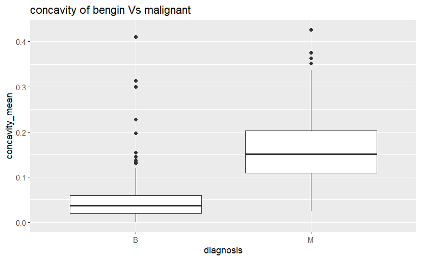

```r
ggplot(data2, aes(x=diagnosis, y=concavity_mean))+geom_boxplot()+ggtitle("concavity of bengin Vs malignant")
```

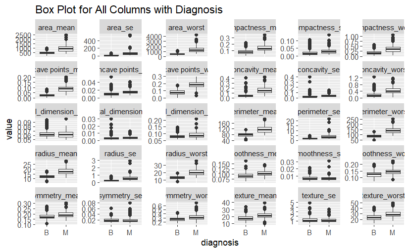

```r
# Reshape the data
data_long <- data2 %>%
  pivot_longer(cols = -diagnosis, names_to = "variable", values_to = "value")

# Plot box plots with separate y-axis scales and arranged in a grid
ggplot(data_long, aes(x = diagnosis, y = value)) +
  geom_boxplot() +
  facet_wrap(~ variable, nrow = 5, ncol = 6, scales = "free_y") +
  ggtitle("Box Plot for All Columns with Diagnosis")
```

### 5-Visualise distribution of data(histograms Plot)

#### a-Histograms of data “_mean”:

```r
#Break up columns into groups, according to their suffix designation
#(_mean, _se,and __worst) to perform visualisation plots off.
data_mean <- data[ ,c("diagnosis", "radius_mean", "texture_mean","perimeter_mean", "area_mean", "smoothness_mean", "compactness_mean", "concavity_mean", "concave points_mean", "symmetry_mean", "fractal_dimension_mean" )]

data_se <- data[ ,c("diagnosis", "radius_se", "texture_se","perimeter_se", "area_se", "smoothness_se", "compactness_se", "concavity_se", "concave points_se", "symmetry_se", "fractal_dimension_se" )]

data_worst <- data[ ,c("diagnosis", "radius_worst", "texture_worst","perimeter_worst", "area_worst", "smoothness_worst", "compactness_worst", "concavity_worst", "concave points_worst", "symmetry_worst", "fractal_dimension_worst" )]
```

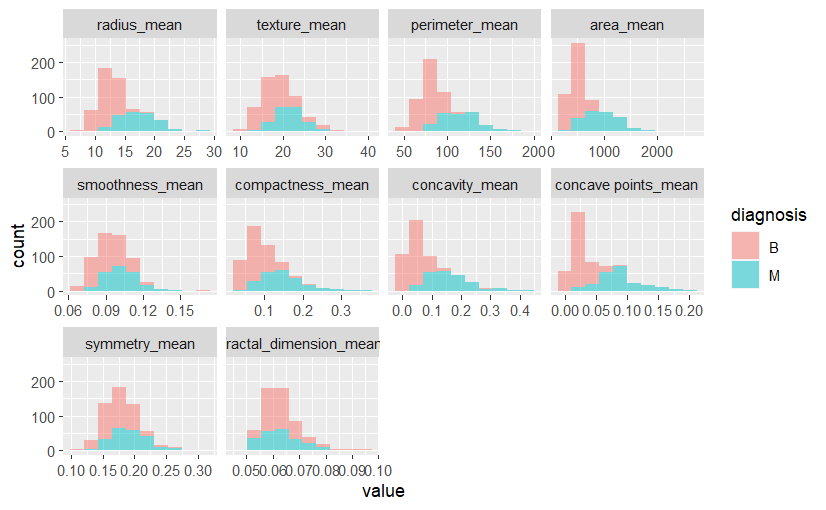

```r
#Plot histograms of "_mean" variables group by diagnosis
ggplot(data = melt(data_mean, id.var = "diagnosis"), mapping = aes(x = value)) +
  geom_histogram(bins = 10, aes(fill=diagnosis), alpha=0.5) + facet_wrap(~variable, scales =      'free_x')
```

#### b- Histograms of data “_se”,“_worst”:

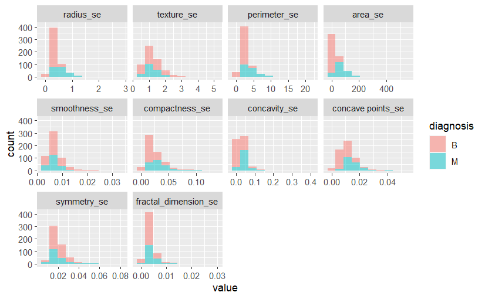

```r
#Plot histograms of "_se" variables group by diagnosis
ggplot(data = melt(data_se, id.var = "diagnosis"), mapping = aes(x = value)) +
  geom_histogram(bins = 10, aes(fill=diagnosis), alpha=0.5) + facet_wrap(~variable, scales = 'free_x')
```

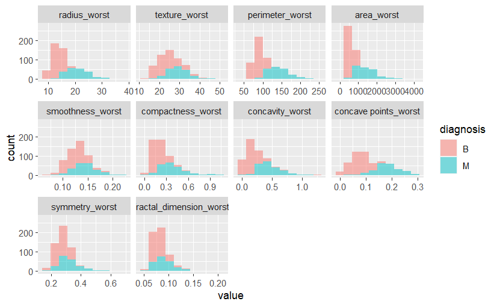

```r
#Plot histograms of "_worst" variables group by diagnosis
ggplot(data = melt(data_worst, id.var = "diagnosis"), mapping = aes(x = value)) +
  geom_histogram(bins = 10, aes(fill=diagnosis), alpha=0.5) + facet_wrap(~variable, scales = 'free_x')
```

# 5.Data preprocessing

Data preprocessing is a vital step in data mining, it involves transforming raw data into a format that is suitable for modeling. The process of data preprocessing contains various techniques and methods to clean, transform, and prepare data before it can be utilized for training models or extracting meaningful insights.

### 1- Data cleaning

Data cleaning involves identifying and correcting or removing inconsistencies, errors, and inaccuracies in the dataset. Missing values need to be handled appropriately to avoid bias or distortion in the analysis. Outliers, which are extreme values that deviate significantly from the majority of the data, can impact the accuracy of models and need to be detected and addressed.

Fortunately, we don’t have any missing values in our dataset, but we were able to identify a total of 265 outliers using the z-score method. The number of outliers for each attribute ranged between 65 and 0, with area_se having the most outliers, and texture_worst, smoothness_worst, and concave points_worst having the fewest outliers.

We did not remove all the outlier objects because there were over 100 of them and removing all of them could compromise the data’s integrity. To settle the issue, we decided to remove the most frequent outlier objects.

To know which objects were the most frequent outliers, we counted the number of times an object became an outlier to a certain attribute, it ranged between 11 to 0, with object number 462 being the most frequent outlier, then we decided that every object that was an outlier more than five times will be deleted, therefore we deleted a total of 13 object.

```r
#Checking NULL, FALSE means no null, TRUE cells means the value of the cell is null
is.na(data1)
```

[output not shown]

[output cut: 151 more lines]

```r
# to find the total null values in the dataset
sum(is.na(data1))
```

```
[1] 0
```

#### Outliers

```r
data2 <- subset(data1, select = -diagnosis)
# Function to identify outliers using z-score
find_outliers <- function(column) {
  median_val <- median(column)
  mad_val <- mad(column)
  modified_z_scores <- 0.6745 * (column - median_val) / mad_val
  return(which(abs(modified_z_scores) > 3))
}
# Function to count outliers for each attribute
count_outliers <- function(data) {
  outlier_counts <- sapply(data, function(col) length(find_outliers(col)))
  return(outlier_counts)
}
# Apply the count_outliers function to the data frame
outlier_counts <- count_outliers(data2)
# Print the outlier counts for each attribute
cat("Outlier counts for each attribute:\n")
```

```
Outlier counts for each attribute:
```

```r
print(outlier_counts)
```

```
            radius_mean            texture_mean          perimeter_mean               area_mean
                      3                       1                       5                      12
        smoothness_mean        compactness_mean          concavity_mean     concave points_mean
                      1                       2                       9                       6
          symmetry_mean  fractal_dimension_mean               radius_se              texture_se
                      1                       5                      19                       4
           perimeter_se                 area_se           smoothness_se          compactness_se
                     21                      65                       8                      12
           concavity_se       concave points_se             symmetry_se    fractal_dimension_se
                     10                       5                      13                      15
           radius_worst           texture_worst         perimeter_worst              area_worst
                      4                       0                       6                      21
       smoothness_worst       compactness_worst         concavity_worst    concave points_worst
                      0                       6                       3                       0
         symmetry_worst fractal_dimension_worst
                      5                       3
```

```r
# Create an empty list to store outlier indices for each attribute
outlier_indices <- list()
# Apply the find_outliers function to each attribute in the data frame
for (col in names(data2)) {
  outlier_indices[[col]] <- find_outliers(data2[[col]])
}
# Print the outlier indices
print(outlier_indices)
```

```
$radius_mean
[1] 181 213 462

$texture_mean
[1] 240

$perimeter_mean
[1]  83 181 213 353 462

$area_mean
 [1]  83 123 165 181 203 213 237 340 353 462 504 522

$smoothness_mean
[1] 505

$compactness_mean
[1]  79 259

$concavity_mean
[1]  79  83 109 123 153 203 353 462 568

$`concave points_mean`
[1]  83 109 123 181 353 462

$symmetry_mean
[1] 26

$fractal_dimension_mean
[1]   4  72 153 505 506

$radius_se
 [1]   1  26  39 109 123 139 169 213 237 259 266 273 301 303 369 418 462 504 565

$texture_se
[1]  13 193 474 562

$perimeter_se
 [1]   1  13  39  43  79  83 109 123 139 213 259 266 273 303 369 370 418 462 504 564 565

$area_se
```

[output cut: 36 more lines]

```

$compactness_worst
[1]   4  10 191 380 563 568

$concavity_worst
[1]  10  69 563

$`concave points_worst`
integer(0)

$symmetry_worst
[1]   4  79 147 191 324

$fractal_dimension_worst
[1]   4  10 152
```

```r
# Flatten the outlier indices into a single vector
flattened_indices <- unlist(outlier_indices)
# Get the outlier counts
outlier_counts <- table(flattened_indices)
# Print the outlier counts
cat("Outlier counts:\n")
```

```
Outlier counts:
```

```r
print(outlier_counts)
```

```
flattened_indices
  1   3   4   5  10  13  19  24  25  26  28  31  39  43  54  57  69  71  72  78  79  83  84  96 109 113 117 120 122
  3   1   5   1   3   7   2   2   2   3   1   1   3   4   1   2   3   1   4   1   7   8   1   1   7   2   1   1   1
123 139 147 152 153 157 162 163 165 169 177 181 191 193 203 211 213 214 215 219 220 237 240 246 251 253 257 259 263
 10   4   2   2   6   1   1   2   3   2   3   8   6   1   2   1   8   5   1   1   2   4   1   1   1   1   1   4   1
266 273 289 291 301 303 315 324 336 338 340 346 352 353 367 369 370 377 380 389 390 418 434 461 462 469 474 486 493
  6   4   2   2   2   3   2   1   1   1   3   1   1   8   1   4   3   2   1   1   1   3   1   1  11   2   1   1   1
499 504 505 506 522 534 536 562 563 564 565 566 568
  1   6   3   3   3   1   1   1   2   2   3   1   3
```

```r
# Get the total count of outliers
total_outliers <- sum(outlier_counts)
# Print the total count of outliers
cat("Total count of outliers:", total_outliers, "\n")
```

```
Total count of outliers: 265
```

```r
# Get the most frequent outlier objects
most_frequent_outlier_objects <- if (length(flattened_indices) > 0) {
  table(flattened_indices)
} else {
  NULL
}
# Sort the most frequent outlier objects in descending order
sorted_most_frequent_outliers <- sort(most_frequent_outlier_objects, decreasing = TRUE)
# Get the outlier objects with a frequency greater than 5
frequent_outliers <- sorted_most_frequent_outliers[sorted_most_frequent_outliers > 5]
# Print the outlier objects with their frequencies
cat("Outlier objects with a frequency greater than 5:\n")
```

```
Outlier objects with a frequency greater than 5:
```

```r
for (row in names(frequent_outliers)) {
  cat("Object", row, "- Frequency:", frequent_outliers[row], "\n")
}
```

```
Object 462 - Frequency: 11
Object 123 - Frequency: 10
Object 83 - Frequency: 8
Object 181 - Frequency: 8
Object 213 - Frequency: 8
Object 353 - Frequency: 8
Object 13 - Frequency: 7
Object 79 - Frequency: 7
Object 109 - Frequency: 7
Object 153 - Frequency: 6
Object 191 - Frequency: 6
Object 266 - Frequency: 6
Object 504 - Frequency: 6
```

```r
# Identify the objects to be deleted
objects_to_delete <- as.integer(names(frequent_outliers))
# Delete the objects from the data frame
data1 <- data1[-objects_to_delete, ]
```

### 2- Data reduction

We had an attribute in our dataset that was entirely made up of null values, thus we had to eliminate it under dimensionality reduction, attribute subset reduction, because it was an irrelevant attribute that contained no useful information.

All the other attributes were relevant to the class label where they describe the mass such as its radius, area or the texture, but the id attribute is not relevant to the class label since it does not describe the mass in any sense, so we had to perform dimensionality reduction that falls under attribute subset reduction, since the id didn’t contain any useful information.

### 3- Attribute transformation

After data reduction, all the remaining attributes were numeric except for the diagnosis, which was nominal, precisely categorical Asymmetric Binary, where M stands for malignant and B stands for benign, so we had to perform an attribute transformation on the diagnosis in which we encoded every B to become 0, and every M to become 1.

```r
data1$diagnosis <- ifelse(data1$diagnosis == "M", 1, ifelse(data1$diagnosis == "B", 0, data1$diagnosis))
# Convert the target variable to numeric or logical
data1$diagnosis <- as.numeric(data1$diagnosis)
head(data1)
```

| radius_mean | texture_mean | perimeter_mean | area_mean | smoothness_mean | compactness_mean | concavity_mean | concave points_mean | symmetry_mean | fractal_dimension_mean | radius_se | texture_se | perimeter_se | area_se | smoothness_se | compactness_se | concavity_se | concave points_se | symmetry_se | fractal_dimension_se | radius_worst | texture_worst | perimeter_worst | area_worst | smoothness_worst | compactness_worst | concavity_worst | concave points_worst | symmetry_worst | fractal_dimension_worst | … |
| --- | --- | --- | --- | --- | --- | --- | --- | --- | --- | --- | --- | --- | --- | --- | --- | --- | --- | --- | --- | --- | --- | --- | --- | --- | --- | --- | --- | --- | --- | --- |
| 17.99 | 10.38 | 122.80 | 1001.0 | 0.11840 | 0.27760 | 0.3001 | 0.14710 | 0.2419 | 0.07871 | 1.0950 | 0.9053 | 8.589 | 153.40 | 0.006399 | 0.04904 | 0.05373 | 0.01587 | 0.03003 | 0.006193 | 25.38 | 17.33 | 184.60 | 2019.0 | 0.1622 | 0.6656 | 0.7119 | 0.2654 | 0.4601 | 0.11890 | … |
| 20.57 | 17.77 | 132.90 | 1326.0 | 0.08474 | 0.07864 | 0.0869 | 0.07017 | 0.1812 | 0.05667 | 0.5435 | 0.7339 | 3.398 | 74.08 | 0.005225 | 0.01308 | 0.01860 | 0.01340 | 0.01389 | 0.003532 | 24.99 | 23.41 | 158.80 | 1956.0 | 0.1238 | 0.1866 | 0.2416 | 0.1860 | 0.2750 | 0.08902 | … |
| 19.69 | 21.25 | 130.00 | 1203.0 | 0.10960 | 0.15990 | 0.1974 | 0.12790 | 0.2069 | 0.05999 | 0.7456 | 0.7869 | 4.585 | 94.03 | 0.006150 | 0.04006 | 0.03832 | 0.02058 | 0.02250 | 0.004571 | 23.57 | 25.53 | 152.50 | 1709.0 | 0.1444 | 0.4245 | 0.4504 | 0.2430 | 0.3613 | 0.08758 | … |
| 11.42 | 20.38 | 77.58 | 386.1 | 0.14250 | 0.28390 | 0.2414 | 0.10520 | 0.2597 | 0.09744 | 0.4956 | 1.1560 | 3.445 | 27.23 | 0.009110 | 0.07458 | 0.05661 | 0.01867 | 0.05963 | 0.009208 | 14.91 | 26.50 | 98.87 | 567.7 | 0.2098 | 0.8663 | 0.6869 | 0.2575 | 0.6638 | 0.17300 | … |
| 20.29 | 14.34 | 135.10 | 1297.0 | 0.10030 | 0.13280 | 0.1980 | 0.10430 | 0.1809 | 0.05883 | 0.7572 | 0.7813 | 5.438 | 94.44 | 0.011490 | 0.02461 | 0.05688 | 0.01885 | 0.01756 | 0.005115 | 22.54 | 16.67 | 152.20 | 1575.0 | 0.1374 | 0.2050 | 0.4000 | 0.1625 | 0.2364 | 0.07678 | … |
| 12.45 | 15.70 | 82.57 | 477.1 | 0.12780 | 0.17000 | 0.1578 | 0.08089 | 0.2087 | 0.07613 | 0.3345 | 0.8902 | 2.217 | 27.19 | 0.007510 | 0.03345 | 0.03672 | 0.01137 | 0.02165 | 0.005082 | 15.47 | 23.75 | 103.40 | 741.6 | 0.1791 | 0.5249 | 0.5355 | 0.1741 | 0.3985 | 0.12440 | … |

### 4- Feature scaling

The scale() function is utilized to calculate the mean and standard deviation of the selected columns (1 to 30). Each element in the columns is then scaled by subtracting the mean and dividing by the standard deviation. Feature scaling is essential as it brings the features to a standardized range, preventing any single feature from dominating the learning process due to differences in scale.

```r
#scale, with default settings, will calculate the mean and standard deviation of the entire vector, then "scale" each element by those values by subtracting the mean and dividing by the sd
data1 [, 1:30] = scale(data1 [, 1:30])
head(data1)
```

| radius_mean | texture_mean | perimeter_mean | area_mean | smoothness_mean | compactness_mean | concavity_mean | concave points_mean | symmetry_mean | fractal_dimension_mean | radius_se | texture_se | perimeter_se | area_se | smoothness_se | compactness_se | concavity_se | concave points_se | symmetry_se | fractal_dimension_se | radius_worst | texture_worst | perimeter_worst | area_worst | smoothness_worst | compactness_worst | concavity_worst | concave points_worst | symmetry_worst | fractal_dimension_worst | … |
| --- | --- | --- | --- | --- | --- | --- | --- | --- | --- | --- | --- | --- | --- | --- | --- | --- | --- | --- | --- | --- | --- | --- | --- | --- | --- | --- | --- | --- | --- | --- |
| 1.2457500 | -2.0628389 | 1.4456750 | 1.1889198 | 1.6271099 | 3.5606818 | 3.01494969 | 2.8163721 | 2.32625624 | 2.3242914 | 3.1575252 | -0.55323040 | 3.7337296 | 3.7283441 | -0.2059213 | 1.493988137 | 0.9316238 | 0.75456910 | 1.2924058 | 1.05359900 | 2.0893090 | -1.355822795 | 2.56558656 | 2.3260418 | 1.3171822 | 2.7311623 | 2.2123717 | 2.4044160 | 2.8342107 | 1.9641962 | … |
| 2.0416859 | -0.3373557 | 1.9005373 | 2.2407131 | -0.8252237 | -0.4684711 | 0.04251406 | 0.6569241 | 0.03032751 | -0.8746102 | 0.7039545 | -0.87280647 | 0.4369555 | 1.1943189 | -0.6066636 | -0.707051872 | -0.4708177 | 0.32245741 | -0.8349177 | -0.07219128 | 2.0021299 | -0.357019493 | 1.72865957 | 2.2009709 | -0.3687675 | -0.4127266 | -0.1149316 | 1.1580147 | -0.2337660 | 0.2940985 | … |
| 1.7702039 | 0.4751857 | 1.7699332 | 1.8426497 | 0.9859769 | 1.1771308 | 1.58310569 | 2.2774224 | 1.00240936 | -0.3927430 | 1.6030781 | -0.77398773 | 1.1908123 | 1.8316588 | -0.2909169 | 0.944340214 | 0.3164338 | 1.57855535 | 0.2999185 | 0.36737884 | 1.6847085 | -0.008752553 | 1.52429368 | 1.7106137 | 0.5356743 | 1.1487163 | 0.9183257 | 2.0527864 | 1.1966305 | 0.2136119 | … |
| -0.7811100 | 0.2720504 | -0.5908471 | -0.8010732 | 3.3829401 | 3.6882635 | 2.19655395 | 1.6402266 | 2.99952694 | 5.0427772 | 0.4908520 | -0.08579912 | 0.4668049 | -0.3023916 | 0.7194726 | 3.057240690 | 1.0465977 | 1.24441230 | 5.1938170 | 2.32915620 | -0.2511149 | 0.150596000 | -0.21541153 | -0.5551544 | 3.4070574 | 4.0484452 | 2.0886579 | 2.2804038 | 6.2104768 | 4.9880345 | … |
| 1.9553053 | -1.1382227 | 1.9996162 | 2.1468607 | 0.3084159 | 0.6283268 | 1.59147090 | 1.6149634 | 0.01898025 | -0.5611062 | 1.6546854 | -0.78442895 | 1.7325477 | 1.8447571 | 1.5318804 | -0.001323527 | 1.0573765 | 1.27590222 | -0.3511954 | 0.59752913 | 1.4544662 | -1.464245521 | 1.51456197 | 1.4445899 | 0.2283397 | -0.2919593 | 0.6689188 | 0.7891176 | -0.8735493 | -0.3900379 | … |
| -0.4633526 | -0.8206778 | -0.3661181 | -0.5065711 | 2.3119565 | 1.3816666 | 1.03100227 | 0.9578377 | 1.07049292 | 1.9498284 | -0.2258665 | -0.58138441 | -0.3130908 | -0.3036695 | 0.1733161 | 0.539755274 | 0.2525595 | -0.03267891 | 0.1878847 | 0.58356781 | -0.1259347 | -0.301165361 | -0.06846272 | -0.2099191 | 2.0591757 | 1.8076859 | 1.3394474 | 0.9712115 | 1.8132093 | 2.2716105 | … |

### 5- Normalization

Normalization is a preprocessing technique that scales numerical features to a consistent range, typically between 0 and 1. By applying the normalize() function to the selected columns, the code ensures that no single feature dominates the learning process due to differences in scale. This normalization step is valuable for improving the performance and stability of data mining algorithms.

```r
# Define function normalize()
normalize <- function(x) {
  return((x - min(x)) / (max(x) - min(x)))
}
cols_to_normalize <- 1:(ncol(data1) - 1)  # Select all columns except the last one
data1[, cols_to_normalize] <- lapply(data1[, cols_to_normalize], normalize)
head(data1)
```

| radius_mean | texture_mean | perimeter_mean | area_mean | smoothness_mean | compactness_mean | concavity_mean | concave points_mean | symmetry_mean | fractal_dimension_mean | radius_se | texture_se | perimeter_se | area_se | smoothness_se | compactness_se | concavity_se | concave points_se | symmetry_se | fractal_dimension_se | radius_worst | texture_worst | perimeter_worst | area_worst | smoothness_worst | compactness_worst | concavity_worst | concave points_worst | symmetry_worst | fractal_dimension_worst | … |
| --- | --- | --- | --- | --- | --- | --- | --- | --- | --- | --- | --- | --- | --- | --- | --- | --- | --- | --- | --- | --- | --- | --- | --- | --- | --- | --- | --- | --- | --- | --- |
| 0.6237747 | 0.0226581 | 0.6491661 | 0.5051546 | 0.5539697 | 0.8842545 | 0.8518308 | 0.9080247 | 0.6863636 | 0.6055181 | 0.7814859 | 0.12046941 | 0.8364840 | 0.67464036 | 0.1592956 | 0.4492453 | 0.17685978 | 0.4041253 | 0.4133786 | 0.2412088 | 0.7560659 | 0.1415245 | 0.8624590 | 0.6199878 | 0.6011358 | 0.6192916 | 0.5686102 | 0.9142267 | 0.5984624 | 0.4188640 | … |
| 0.7699586 | 0.2725736 | 0.7321502 | 0.6966127 | 0.2203390 | 0.2029313 | 0.2466648 | 0.4331481 | 0.3797980 | 0.1413227 | 0.3432658 | 0.08258929 | 0.2820677 | 0.30961169 | 0.1193867 | 0.1039674 | 0.06122449 | 0.3412274 | 0.1121356 | 0.1200626 | 0.7391681 | 0.3035714 | 0.6966386 | 0.5986882 | 0.3475533 | 0.1545634 | 0.1929712 | 0.6407165 | 0.2335896 | 0.2228781 | … |
| 0.7200975 | 0.3902604 | 0.7083231 | 0.6241532 | 0.4667460 | 0.4811999 | 0.5603179 | 0.7895062 | 0.5095960 | 0.2112468 | 0.5038538 | 0.09430251 | 0.4088433 | 0.40142109 | 0.1508312 | 0.3630219 | 0.12613562 | 0.5240642 | 0.2728359 | 0.1673647 | 0.6776430 | 0.3600746 | 0.6561476 | 0.5151802 | 0.4835898 | 0.3853751 | 0.3597444 | 0.8370651 | 0.4037059 | 0.2134330 | … |
| 0.2515157 | 0.3608387 | 0.2776271 | 0.1429161 | 0.7928437 | 0.9058284 | 0.6852115 | 0.6493827 | 0.7762626 | 1.0000000 | 0.3052046 | 0.17587518 | 0.2870875 | 0.09400915 | 0.2514532 | 0.6944732 | 0.18633970 | 0.4754265 | 0.9658442 | 0.3784714 | 0.3024263 | 0.3859275 | 0.3114596 | 0.1293191 | 0.9154725 | 0.8140117 | 0.5486422 | 0.8870134 | 1.0000000 | 0.7737111 | … |
| 0.7540937 | 0.1565776 | 0.7502259 | 0.6795287 | 0.3745664 | 0.3883981 | 0.5620210 | 0.6438272 | 0.3782828 | 0.1868155 | 0.5130711 | 0.09306489 | 0.4999466 | 0.40330790 | 0.3323588 | 0.2146753 | 0.18722844 | 0.4800102 | 0.1806338 | 0.1921312 | 0.6330156 | 0.1239339 | 0.6542194 | 0.4698763 | 0.4373638 | 0.1724151 | 0.3194888 | 0.5597658 | 0.1575005 | 0.1425948 | … |
| 0.3098759 | 0.2025702 | 0.3186262 | 0.1965243 | 0.6471404 | 0.5157866 | 0.4479137 | 0.4993210 | 0.5186869 | 0.5511794 | 0.1771951 | 0.11713225 | 0.1559329 | 0.09382507 | 0.1970629 | 0.2995545 | 0.12086899 | 0.2895340 | 0.2569711 | 0.1906288 | 0.3266898 | 0.3126333 | 0.3405746 | 0.1881128 | 0.7127386 | 0.4827837 | 0.4277157 | 0.5997244 | 0.4770353 | 0.4549390 | … |

### 6- Discretization

Based on the selected data set we decided to use equal width in discretization process , performed on the selected columns. We selected all numeric countinues attributes (In this case, all columns except the last one were selected), and divided using equal width with 20 bins.

The reason for choosing an equal-width distribution in this case is to divide the range of values in each selected column into a fixed number of equal-sized bins. This provides us with several features that help us in analysis:

1- Simplicity and interpretability: Equal width divides the range of values into equal-sized intervals, making the resulting categories easier to interpret.

2- Preserving the distribution: By dividing the range into equal intervals, it ensures that each bin covers an equal width of the data range, allowing for a more balanced representation of values.

```r
# Number of bins for discretization
num_bins <- 20
# Function to perform discretization using equal width
equal_width_discretize <- function(var, num_bins) {
  breaks <- seq(min(var, na.rm = TRUE), max(var, na.rm = TRUE), length.out = num_bins + 1)
  cut(var, breaks = breaks, labels = FALSE)
}
# Subset the dataset with selected columns
cols_to_Discretiz <- 1:(ncol(data1) - 1)  # Select all columns except the last one
# Apply equal width discretization to selected columns
data1_discretized <- lapply(data1[, cols_to_Discretiz], equal_width_discretize, num_bins)
# Replace null values with 0
data1_discretized <- lapply(data1_discretized, function(x) ifelse(is.na(x), 0, x))
# Assign discretized values back to the original dataset
data1[, cols_to_Discretiz] <- data1_discretized
# View the modified dataset
head(data1)
```

| radius_mean | texture_mean | perimeter_mean | area_mean | smoothness_mean | compactness_mean | concavity_mean | concave points_mean | symmetry_mean | fractal_dimension_mean | radius_se | texture_se | perimeter_se | area_se | smoothness_se | compactness_se | concavity_se | concave points_se | symmetry_se | fractal_dimension_se | radius_worst | texture_worst | perimeter_worst | area_worst | smoothness_worst | compactness_worst | concavity_worst | concave points_worst | symmetry_worst | fractal_dimension_worst | … |
| --- | --- | --- | --- | --- | --- | --- | --- | --- | --- | --- | --- | --- | --- | --- | --- | --- | --- | --- | --- | --- | --- | --- | --- | --- | --- | --- | --- | --- | --- | --- |
| 13 | 1 | 13 | 11 | 12 | 18 | 18 | 19 | 14 | 13 | 16 | 3 | 17 | 14 | 4 | 9 | 4 | 9 | 9 | 5 | 16 | 3 | 18 | 13 | 13 | 13 | 12 | 19 | 12 | 9 | … |
| 16 | 6 | 15 | 14 | 5 | 5 | 5 | 9 | 8 | 3 | 7 | 2 | 6 | 7 | 3 | 3 | 2 | 7 | 3 | 3 | 15 | 7 | 14 | 12 | 7 | 4 | 4 | 13 | 5 | 5 | … |
| 15 | 8 | 15 | 13 | 10 | 10 | 12 | 16 | 11 | 5 | 11 | 2 | 9 | 9 | 4 | 8 | 3 | 11 | 6 | 4 | 14 | 8 | 14 | 11 | 10 | 8 | 8 | 17 | 9 | 5 | … |
| 6 | 8 | 6 | 3 | 16 | 19 | 14 | 13 | 16 | 20 | 7 | 4 | 6 | 2 | 6 | 14 | 4 | 10 | 20 | 8 | 7 | 8 | 7 | 3 | 19 | 17 | 11 | 18 | 20 | 16 | … |
| 16 | 4 | 16 | 14 | 8 | 8 | 12 | 13 | 8 | 4 | 11 | 2 | 10 | 9 | 7 | 5 | 4 | 10 | 4 | 4 | 13 | 3 | 14 | 10 | 9 | 4 | 7 | 12 | 4 | 3 | … |
| 7 | 5 | 7 | 4 | 13 | 11 | 9 | 10 | 11 | 12 | 4 | 3 | 4 | 2 | 4 | 6 | 3 | 6 | 6 | 4 | 7 | 7 | 7 | 4 | 15 | 10 | 9 | 12 | 10 | 10 | … |

### 7- Feature selection

We performed a feature selection by assessing the importance of attributes in the dataset. The code trains a linear regression model and calculates the importance of each attribute. The least important 9 attributes were identified by their importance being under 0.5, these attributes were symmetry_se, fractal_dimension_mean, texture_mean, concave points_se, perimeter_se, symmetry_mean, compactness_se, smoothness_mean, and compactness_worst, while the highest importance being 3.05 and belonging to compactness_mean. The least important 9 attributes are subsequently recommended for removal, removing the least important 9 attributes can be beneficial for several reasons:

Dimensionality reduction: Removing less important attributes reduces the dimensionality of the dataset, making it more manageable. It simplifies the model and can lead to improved model performance.

Computational efficiency: With fewer attributes, the training and evaluation of the model become faster and more efficient. Removing unnecessary attributes reduces the computational cost associated with processing and analyzing the data.

Simplifying the model: By focusing on the most important attributes, the model becomes more interpretable and easier to understand. It allows for better insights into the relationships between the selected attributes and the target variable.

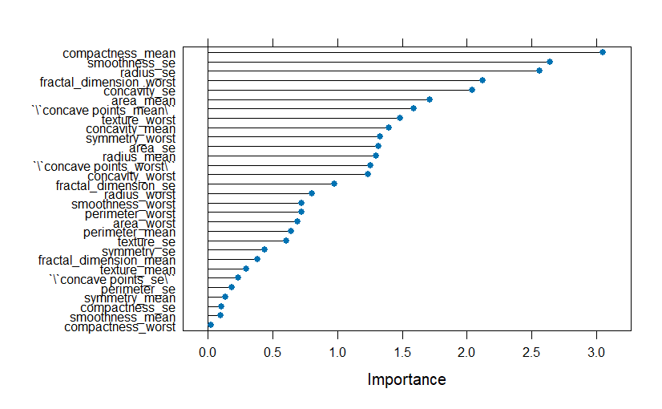

```r
# ensure results are repeatable
set.seed(7)
# prepare training scheme
control4 <- trainControl(method = "repeatedcv", number = 10, repeats = 3)
# train the model
model4 <- train(diagnosis ~.,data = data1 , method="lm", preProcess="scale", trControl=control4)
# estimate variable importance
importance4 <- varImp(model4 , scale=FALSE)
# plot importance
plot(importance4)
```

```r
# train the model
model4 <- lm(diagnosis ~.,data = data1)
# estimate variable importance
importance4 <- varImp(model4 , scale=FALSE)
# Copy the importance3 dataframe to a new dataframe
importance4_copy <- importance4
# Add a column for row names
importance4_copy$name <- row.names(importance4_copy)
# Sort the dataframe based on the "Overall" column in descending order
importance4_copy <- importance4_copy[order(importance4_copy$Overall, decreasing = TRUE), ]
# Reset row names
row.names(importance4_copy) <- NULL
# Print the rearranged dataframe
print(importance4_copy)
```

| Overall | name |
| --- | --- |
| 3.05254419 | compactness_mean |
| 2.63893520 | smoothness_se |
| 2.55959665 | radius_se |
| 2.12475293 | fractal_dimension_worst |
| 2.03905333 | concavity_se |
| 1.71179958 | area_mean |
| 1.59265063 | `concave points_mean` |
| 1.48194626 | texture_worst |
| 1.39856754 | concavity_mean |
| 1.32754174 | symmetry_worst |

[output cut: 20 more lines]

```r
# Remove the least important 9 attributes
data1 <- subset(data1, select = -symmetry_se)
data1 <- subset(data1, select = -fractal_dimension_mean)
data1 <- subset(data1, select = -texture_mean)
data1 <- subset(data1, select = -`concave points_se`)
data1 <- subset(data1, select = -perimeter_se)
data1 <- subset(data1, select = -symmetry_mean)
data1 <- subset(data1, select = -compactness_se)
data1 <- subset(data1, select = -smoothness_mean)
data1 <- subset(data1, select = -compactness_worst)
head(data1)
```

| radius_mean | perimeter_mean | area_mean | compactness_mean | concavity_mean | concave points_mean | radius_se | texture_se | area_se | smoothness_se | concavity_se | fractal_dimension_se | radius_worst | texture_worst | perimeter_worst | area_worst | smoothness_worst | concavity_worst | concave points_worst | symmetry_worst | fractal_dimension_worst | diagnosis |
| --- | --- | --- | --- | --- | --- | --- | --- | --- | --- | --- | --- | --- | --- | --- | --- | --- | --- | --- | --- | --- | --- |
| 13 | 13 | 11 | 18 | 18 | 19 | 16 | 3 | 14 | 4 | 4 | 5 | 16 | 3 | 18 | 13 | 13 | 12 | 19 | 12 | 9 | 1 |
| 16 | 15 | 14 | 5 | 5 | 9 | 7 | 2 | 7 | 3 | 2 | 3 | 15 | 7 | 14 | 12 | 7 | 4 | 13 | 5 | 5 | 1 |
| 15 | 15 | 13 | 10 | 12 | 16 | 11 | 2 | 9 | 4 | 3 | 4 | 14 | 8 | 14 | 11 | 10 | 8 | 17 | 9 | 5 | 1 |
| 6 | 6 | 3 | 19 | 14 | 13 | 7 | 4 | 2 | 6 | 4 | 8 | 7 | 8 | 7 | 3 | 19 | 11 | 18 | 20 | 16 | 1 |
| 16 | 16 | 14 | 8 | 12 | 13 | 11 | 2 | 9 | 7 | 4 | 4 | 13 | 3 | 14 | 10 | 9 | 7 | 12 | 4 | 3 | 1 |
| 7 | 7 | 4 | 11 | 9 | 10 | 4 | 3 | 2 | 4 | 3 | 4 | 7 | 7 | 7 | 4 | 15 | 9 | 12 | 10 | 10 | 1 |

## Data before preprocessing

```r
#Data before preprocessing
rawData <- data
head(rawData)
```

| id | diagnosis | radius_mean | texture_mean | perimeter_mean | area_mean | smoothness_mean | compactness_mean | concavity_mean | concave points_mean | symmetry_mean | fractal_dimension_mean | radius_se | texture_se | perimeter_se | area_se | smoothness_se | compactness_se | concavity_se | concave points_se | symmetry_se | fractal_dimension_se | radius_worst | texture_worst | perimeter_worst | area_worst | smoothness_worst | compactness_worst | concavity_worst | concave points_worst | … |
| --- | --- | --- | --- | --- | --- | --- | --- | --- | --- | --- | --- | --- | --- | --- | --- | --- | --- | --- | --- | --- | --- | --- | --- | --- | --- | --- | --- | --- | --- | --- |
| 842302 | M | 17.99 | 10.38 | 122.80 | 1001.0 | 0.11840 | 0.27760 | 0.3001 | 0.14710 | 0.2419 | 0.07871 | 1.0950 | 0.9053 | 8.589 | 153.40 | 0.006399 | 0.04904 | 0.05373 | 0.01587 | 0.03003 | 0.006193 | 25.38 | 17.33 | 184.60 | 2019.0 | 0.1622 | 0.6656 | 0.7119 | 0.2654 | … |
| 842517 | M | 20.57 | 17.77 | 132.90 | 1326.0 | 0.08474 | 0.07864 | 0.0869 | 0.07017 | 0.1812 | 0.05667 | 0.5435 | 0.7339 | 3.398 | 74.08 | 0.005225 | 0.01308 | 0.01860 | 0.01340 | 0.01389 | 0.003532 | 24.99 | 23.41 | 158.80 | 1956.0 | 0.1238 | 0.1866 | 0.2416 | 0.1860 | … |
| 84300903 | M | 19.69 | 21.25 | 130.00 | 1203.0 | 0.10960 | 0.15990 | 0.1974 | 0.12790 | 0.2069 | 0.05999 | 0.7456 | 0.7869 | 4.585 | 94.03 | 0.006150 | 0.04006 | 0.03832 | 0.02058 | 0.02250 | 0.004571 | 23.57 | 25.53 | 152.50 | 1709.0 | 0.1444 | 0.4245 | 0.4504 | 0.2430 | … |
| 84348301 | M | 11.42 | 20.38 | 77.58 | 386.1 | 0.14250 | 0.28390 | 0.2414 | 0.10520 | 0.2597 | 0.09744 | 0.4956 | 1.1560 | 3.445 | 27.23 | 0.009110 | 0.07458 | 0.05661 | 0.01867 | 0.05963 | 0.009208 | 14.91 | 26.50 | 98.87 | 567.7 | 0.2098 | 0.8663 | 0.6869 | 0.2575 | … |
| 84358402 | M | 20.29 | 14.34 | 135.10 | 1297.0 | 0.10030 | 0.13280 | 0.1980 | 0.10430 | 0.1809 | 0.05883 | 0.7572 | 0.7813 | 5.438 | 94.44 | 0.011490 | 0.02461 | 0.05688 | 0.01885 | 0.01756 | 0.005115 | 22.54 | 16.67 | 152.20 | 1575.0 | 0.1374 | 0.2050 | 0.4000 | 0.1625 | … |
| 843786 | M | 12.45 | 15.70 | 82.57 | 477.1 | 0.12780 | 0.17000 | 0.1578 | 0.08089 | 0.2087 | 0.07613 | 0.3345 | 0.8902 | 2.217 | 27.19 | 0.007510 | 0.03345 | 0.03672 | 0.01137 | 0.02165 | 0.005082 | 15.47 | 23.75 | 103.40 | 741.6 | 0.1791 | 0.5249 | 0.5355 | 0.1741 | … |

## Preprocessed data

```r
#Preprocessed data
preprocessedData <- data1
head(preprocessedData)
```

| radius_mean | perimeter_mean | area_mean | compactness_mean | concavity_mean | concave points_mean | radius_se | texture_se | area_se | smoothness_se | concavity_se | fractal_dimension_se | radius_worst | texture_worst | perimeter_worst | area_worst | smoothness_worst | concavity_worst | concave points_worst | symmetry_worst | fractal_dimension_worst | diagnosis |
| --- | --- | --- | --- | --- | --- | --- | --- | --- | --- | --- | --- | --- | --- | --- | --- | --- | --- | --- | --- | --- | --- |
| 13 | 13 | 11 | 18 | 18 | 19 | 16 | 3 | 14 | 4 | 4 | 5 | 16 | 3 | 18 | 13 | 13 | 12 | 19 | 12 | 9 | 1 |
| 16 | 15 | 14 | 5 | 5 | 9 | 7 | 2 | 7 | 3 | 2 | 3 | 15 | 7 | 14 | 12 | 7 | 4 | 13 | 5 | 5 | 1 |
| 15 | 15 | 13 | 10 | 12 | 16 | 11 | 2 | 9 | 4 | 3 | 4 | 14 | 8 | 14 | 11 | 10 | 8 | 17 | 9 | 5 | 1 |
| 6 | 6 | 3 | 19 | 14 | 13 | 7 | 4 | 2 | 6 | 4 | 8 | 7 | 8 | 7 | 3 | 19 | 11 | 18 | 20 | 16 | 1 |
| 16 | 16 | 14 | 8 | 12 | 13 | 11 | 2 | 9 | 7 | 4 | 4 | 13 | 3 | 14 | 10 | 9 | 7 | 12 | 4 | 3 | 1 |
| 7 | 7 | 4 | 11 | 9 | 10 | 4 | 3 | 2 | 4 | 3 | 4 | 7 | 7 | 7 | 4 | 15 | 9 | 12 | 10 | 10 | 1 |

# 6. Classification

### 1- Convert the response variable to a factor

The objective of this script is to prepare the dataset for classification analysis by converting the response variable into a factor. The “diagnosis,” is transformed into a factor with levels 0 and 1.

To enhance the clarity and consistency of the preprocessedData dataset by renaming specific columns. Specifically, columns with indices 6 and 19 are renamed to “concave_points_mean” and “concave_points_worst,” respectively, to address the presence of spaces in their original names.

```r
colnames(preprocessedData)[6] <- "concave_points_mean"
colnames(preprocessedData)[19] <- "concave_points_worst"
preprocessedData$diagnosis <- factor(preprocessedData$diagnosis, levels = c(0, 1))
```

```r
# Load required libraries
library(party)
library(FSelector)
library(partykit)
library(caret)
```

### 2- Partitioning Method

We used the Holdout Partitioning Method to partition the preprocessed dataset into training and testing sets using different partition methods. The three partition methods involve creating splits of 70-30, 60-40, and 80-20 ratios between the training and testing sets.

The holdout method is a widely used technique in Data mining for partitioning a dataset into training and testing sets. It involves splitting the dataset into two subsets: one for training the model and the other for evaluating its performance. The primary reasons for the popularity of the holdout method include its simplicity, ease of implementation, and ability to provide a quick assessment of a model’s performance.

#### a- Seed for Reproducibility:

The code begins by setting a seed (seed value: 7) to ensure reproducibility. This is a good practice, especially when random processes are involved in the data partitioning.

```r
# Set seed for reproducibility
set.seed(7)

# Different partition methods (70-30, 60-40, and 80-20 splits)
ind1 <- sample(2, nrow(preprocessedData), replace=TRUE, prob=c(0.7, 0.3))
ind2 <- sample(2, nrow(preprocessedData), replace=TRUE, prob=c(0.6, 0.4))
ind3 <- sample(2, nrow(preprocessedData), replace=TRUE, prob=c(0.8, 0.2))

trainData1 <- preprocessedData[ind1 == 1,]
testData1 <- preprocessedData[ind1 == 2,]

trainData2 <- preprocessedData[ind2 == 1,]
testData2 <- preprocessedData[ind2 == 2,]

trainData3 <- preprocessedData[ind3 == 1,]
testData3 <- preprocessedData[ind3 == 2,]
```

Prepare the training and testing datasets (trainData1, trainData2, trainData3, testData1, testData2, testData3) for machine learning modeling by converting the “diagnosis” variable into a factor variable. Additionally, it ensures consistent factor levels between the training and testing datasets.

```r
# Convert diagnosis to a factor variable
trainData1$diagnosis <- factor(trainData1$diagnosis, levels = c(0, 1))
trainData2$diagnosis <- factor(trainData2$diagnosis, levels = c(0, 1))
trainData3$diagnosis <- factor(trainData3$diagnosis, levels = c(0, 1))

# Ensure consistent factor levels in training and test data
testData1$diagnosis <- factor(testData1$diagnosis, levels = c(0, 1))
testData2$diagnosis <- factor(testData2$diagnosis, levels = c(0, 1))
testData3$diagnosis <- factor(testData3$diagnosis, levels = c(0, 1))
```

### 3- Attribute selecting measures

#### a- Information Gain

To develop decision tree models using the Information Gain method for attribute selection. The C50 algorithm is employed for this purpose. The script creates three decision tree models with different training datasets, each representing a distinct split ratio (70-30, 60-40, and 80-20).

##### 1. library of Information Gain trees

The C5.0 function from the C50 package in R does not have a direct argument to specify the attribute selection measure (such as Information Gain, Information Gain Ratio, or Gini Index), However, we used the C5.0() function without specifying the attribute selection measure, and it will automatically use Information Gain for decision tree construction because Information Gain is the default attribute selecting measure.

```r
#Information Gain method for selecting attributes using C50 algorithm
# Load required library for Information Gain
library(C50)

# Set seed for reproducibility
set.seed(7)

# Define the formula for the decision tree
formula_info_gain <- diagnosis ~ .

# Fit decision tree models using Information Gain
# Build decision tree model using Information Gain selected attributes (70-30 split)
model_info_gain1 <- C5.0(formula_info_gain, data = trainData1)
# Build decision tree model using Information Gain selected attributes (60-40 split)
model_info_gain2 <- C5.0(formula_info_gain, data = trainData2)
# Build decision tree model using Information Gain selected attributes (80-20 split)
model_info_gain3 <- C5.0(formula_info_gain, data = trainData3)
```

##### 2. plot Information Gain trees

Visually represent the decision trees generated using the Information Gain method with different partition methods (70-30, 60-40, and 80-20 splits). The C50 algorithm is employed for building these decision tree models.

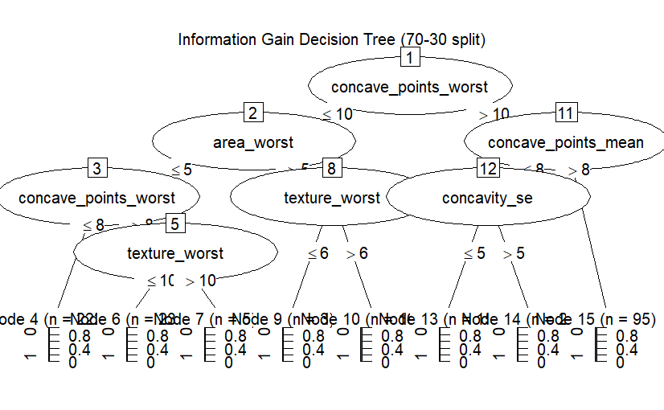

```r
# Plot the decision trees for different partition methods (Information Gain)
# Plot decision tree for (70-30 split)
plot(model_info_gain1, main = "Information Gain Decision Tree (70-30 split)")
```

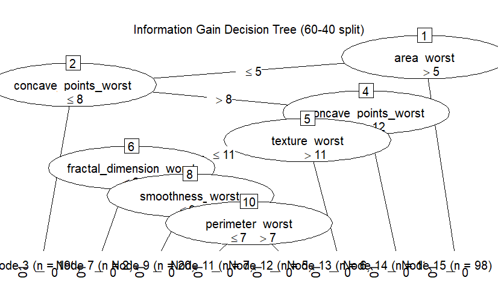

```r
# Plot decision tree for (60-40 split)
plot(model_info_gain2, main = "Information Gain Decision Tree (60-40 split)")
```

[figure not shown]

```r
# Plot decision tree for (80-20 split)
plot(model_info_gain3, main = "Information Gain Decision Tree (80-20 split)")
```

##### 3. Make predictions of Information Gain trees

Make predictions using the decision tree models generated with the Information Gain method. Three sets of predictions are made based on different partition methods (70-30, 60-40, and 80-20 splits). The predictive power of decision tree models is assessed by applying them to previously unseen data. In this case, three decision tree models, generated with varying training and testing splits, are used to predict the class labels of the corresponding test datasets.

```r
#(70-30 split)
predictions_info_gain1 <- predict(model_info_gain1, testData1)
#(60-40 split)
predictions_info_gain2 <- predict(model_info_gain2, testData2)
#(80-20 split)
predictions_info_gain3 <- predict(model_info_gain3, testData3)
```

#### 4. Evaluate the models of Information Gain trees

#### 1. Information Gain trees

we present a comprehensive evaluation of decision tree models generated using the Information Gain method. The assessment includes key performance metrics such as accuracy, precision, sensitivity, and specificity for each model. Additionally, confusion matrices are employed to offer a detailed breakdown of model predictions.

#### 2. Methodology

2.1. Accuracy Calculation The accuracy of each model is computed by comparing the predicted values against the actual values in the test set.

2.2. Precision, Sensitivity, Specificity Calculation A custom function, calculate_metrics, is utilized to compute precision, sensitivity, and specificity based on the confusion matrix.

2.3. Confusion Matrix Generation The conf_matrix function constructs a confusion matrix using the confusionMatrix function from the caret package.

2.4. Print Metrics for Each Split Metrics such as accuracy, precision, sensitivity, specificity, and the confusion matrix are printed for each split to provide a detailed evaluation.

#### 3. Results

3.1. Accuracy (70-30 Split) The accuracy of the Information Gain decision tree model is approximately 89.66%. This implies that the model correctly predicts class labels in nearly 90% of cases on the test set.

(60-40 Split) The accuracy increases to around 93.93% for the 60-40 split, indicating improved performance compared to the 70-30 split.

(80-20 Split) For the 80-20 split, the accuracy is approximately 92.24%, demonstrating consistent performance across different data splits.

3.2. Precision Precision measures the proportion of true positive predictions among all positive predictions.

(70-30 Split) The precision is approximately 88.57%, indicating that when the model predicts the positive class, it is correct around 88.57% of the time.

(60-40 Split) Precision increases to about 92.11% for the 60-40 split, reflecting a higher proportion of true positive predictions among positive predictions.

(80-20 Split) The precision further improves to around 95.12% for the 80-20 split, suggesting high correctness in predicting positive instances.

3.3. Sensitivity Sensitivity measures the proportion of true positive predictions among all actual positive cases.

(70-30 Split) Sensitivity is approximately 86.11%, indicating that the model captures around 86.11% of actual positive instances.

(60-40 Split) Sensitivity increases to about 90.91%, indicating improved performance in correctly identifying positive instances for the 60-40 split.

(80-20 Split) Sensitivity decreases slightly to around 84.78%, suggesting that the model captures a slightly lower proportion of actual positive instances for the 80-20 split.

3.4. Specificity Specificity reflects the proportion of true negative predictions among all actual negative cases.

(70-30 Split) Specificity is approximately 92.16%, indicating a high proportion of correct predictions for the negative class.

(60-40 Split) Specificity increases to about 95.62%, demonstrating improved correctness in predicting negative instances for the 60-40 split.

(80-20 Split) Specificity reaches around 97.14%, showing high correctness in predicting negative instances for the 80-20 split.

3.5. Confusion Matrices Confusion matrices provide a detailed breakdown of model predictions.

#### 4. Overall Assessment

The Information Gain decision tree models exhibit robust performance across various data splits, showcasing high accuracy and maintaining a balanced interplay between precision, sensitivity, and specificity. Among the evaluated splits, the (60-40 Split) configuration emerges as the optimal choice, considering the comprehensive evaluation metrics.

Reasons for (60-40 Split) Preference:

1- Optimal Accuracy: The Information Gain decision tree model achieves the highest accuracy of approximately 93.93% for the 60-40 split, surpassing both the 70-30 and 80-20 splits. This implies superior predictive capabilities on the test set.

2- Balanced Precision and Sensitivity: Precision increases to about 92.11% for the 60-40 split, indicating a higher proportion of true positive predictions among positive predictions. Sensitivity remains strong at around 90.91%, demonstrating the model’s effectiveness in correctly identifying positive instances.

3- High Specificity: Specificity increases to about 95.62% for the 60-40 split, showcasing improved correctness in predicting negative instances. This is crucial for minimizing false negatives and ensuring reliability in identifying non-positive cases.

4- Consistent Performance: The (60-40 Split) maintains a balance between accuracy and other key metrics, demonstrating consistent and reliable performance across different aspects of model evaluation.

While the model’s performance remains commendable across all splits, the (60-40 Split) is recommended as it represents a favorable compromise, providing high accuracy and a well-rounded performance profile.

```r
# Evaluate the models accuracy
#(70-30 split)
accuracy_info_gain1 <- sum(predictions_info_gain1 == testData1$diagnosis) / nrow(testData1)
#(60-40 split)
accuracy_info_gain2 <- sum(predictions_info_gain2 == testData2$diagnosis) / nrow(testData2)
#(80-20 split)
accuracy_info_gain3 <- sum(predictions_info_gain3 == testData3$diagnosis) / nrow(testData3)

# Function to calculate Precision, Sensitivity, Specificity
calculate_metrics <- function(conf_matrix) {
  precision <- conf_matrix[2, 2] / sum(conf_matrix[, 2])
  sensitivity <- conf_matrix[2, 2] / sum(conf_matrix[2, ])
  specificity <- conf_matrix[1, 1] / sum(conf_matrix[1, ])

  return(c(precision, sensitivity, specificity))
}

# Confusion matrix function
conf_matrix <- function(predictions, actual) {
  result <- confusionMatrix(table(predictions, actual))
  result$table
}

#(70-30 split)
conf_matrix_info_gain1 <- conf_matrix(predictions_info_gain1, testData1$diagnosis)
metrics_info_gain1 <- calculate_metrics(conf_matrix_info_gain1)

#(60-40 split)
conf_matrix_info_gain2 <- conf_matrix(predictions_info_gain2, testData2$diagnosis)
metrics_info_gain2 <- calculate_metrics(conf_matrix_info_gain2)

#(80-20 split)
conf_matrix_info_gain3 <- conf_matrix(predictions_info_gain3, testData3$diagnosis)
metrics_info_gain3 <- calculate_metrics(conf_matrix_info_gain3)
```

```r
# Print accuracies and additional metrics for comparison
print("Evaluation Metrics for Information Gain with (70-30 split):")
```

```
[1] "Evaluation Metrics for Information Gain with (70-30 split):"
```

```r
print(paste("Accuracy:", accuracy_info_gain1))
```

```
[1] "Accuracy: 0.896551724137931"
```

```r
print(paste("Precision:", metrics_info_gain1[1]))
```

```
[1] "Precision: 0.885714285714286"
```

```r
print(paste("Sensitivity:", metrics_info_gain1[2]))
```

```
[1] "Sensitivity: 0.861111111111111"
```

```r
print(paste("Specificity:", metrics_info_gain1[3]))
```

```
[1] "Specificity: 0.92156862745098"
```

```r
print("Confusion Matrix:")
```

```
[1] "Confusion Matrix:"
```

```r
print(conf_matrix_info_gain1)
```

```
           actual
predictions  0  1
          0 94  8
          1 10 62
```

```r
print("Evaluation Metrics for Information Gain with (60-40 split):")
```

```
[1] "Evaluation Metrics for Information Gain with (60-40 split):"
```

```r
print(paste("Accuracy:", accuracy_info_gain2))
```

```
[1] "Accuracy: 0.939252336448598"
```

```r
print(paste("Precision:", metrics_info_gain2[1]))
```

```
[1] "Precision: 0.921052631578947"
```

```r
print(paste("Sensitivity:", metrics_info_gain2[2]))
```

```
[1] "Sensitivity: 0.909090909090909"
```

```r
print(paste("Specificity:", metrics_info_gain2[3]))
```

```
[1] "Specificity: 0.956204379562044"
```

```r
print("Confusion Matrix:")
```

```
[1] "Confusion Matrix:"
```

```r
print(conf_matrix_info_gain2)
```

```
           actual
predictions   0   1
          0 131   6
          1   7  70
```

```r
print("Evaluation Metrics for Information Gain with (80-20 split):")
```

```
[1] "Evaluation Metrics for Information Gain with (80-20 split):"
```

```r
print(paste("Accuracy:", accuracy_info_gain3))
```

```
[1] "Accuracy: 0.922413793103448"
```

```r
print(paste("Precision:", metrics_info_gain3[1]))
```

```
[1] "Precision: 0.951219512195122"
```

```r
print(paste("Sensitivity:", metrics_info_gain3[2]))
```

```
[1] "Sensitivity: 0.847826086956522"
```

```r
print(paste("Specificity:", metrics_info_gain3[3]))
```

```
[1] "Specificity: 0.971428571428571"
```

```r
print("Confusion Matrix:")
```

```
[1] "Confusion Matrix:"
```

```r
print(conf_matrix_info_gain3)
```

```
           actual
predictions  0  1
          0 68  2
          1  7 39
```

#### b- Gini Index

This section focuses on constructing decision tree models using the Gini Index method for attribute selection. The decision tree models are built with the rpart algorithm, and the resulting trees are visualized using the rpart.plot library. The goal is to evaluate the performance of the models on different data splits.

#### 1. library of Gini Index trees

The necessary libraries, rpart and rpart.plot, are loaded to facilitate decision tree construction and visualization. rpart package in R has a direct argument to specify the attribute selection measure such as Gini Index, so used The parms argument with list(split = “gini”) in the rpart function to specify additional parameters for the tree-building process. In this case, it indicates the use of the Gini Index as the criterion for splitting nodes in the decision tree.

```r
#Gini Index method for selecting attributes using rpart algorithm
# Load required library for gini
library(rpart)
library(rpart.plot)

# Set seed for reproducibility
set.seed(7)

# Define the formula for the decision tree
formula_gini <- diagnosis ~ .

# Fit decision tree models using Gini Index
# Build decision tree model using Gini Index selected attributes (70-30 split)
model_gini1 <- rpart(formula_gini, data = trainData1, method = "class", parms = list(split = "gini"))
# Build decision tree model using Gini Index selected attributes (60-40 split)
model_gini2 <- rpart(formula_gini, data = trainData2, method = "class", parms = list(split = "gini"))
# Build decision tree model using Gini Index selected attributes (80-20 split)
model_gini3 <- rpart(formula_gini, data = trainData3, method = "class", parms = list(split = "gini"))
```

#### 2. plot Gini Index trees

Visualizing decision trees constructed using the Gini Index method for attribute selection. The decision trees are generated based on different partition methods (70-30, 60-40, and 80-20 splits) to observe how the tree structures vary with different training and testing data subsets.

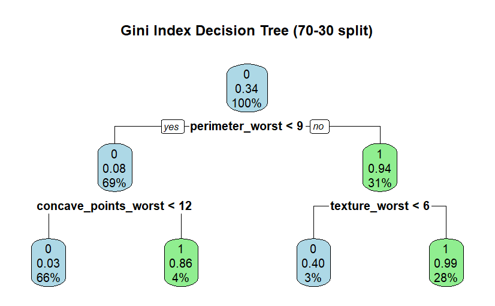

```r
# Plot the decision trees for different partition methods (Gini Index)
# Plot decision tree for (70-30 split)
rpart.plot(model_gini1, type = 2, box.palette = c("lightblue", "lightgreen"), fallen.leaves = TRUE, main = "Gini Index Decision Tree (70-30 split)")
```

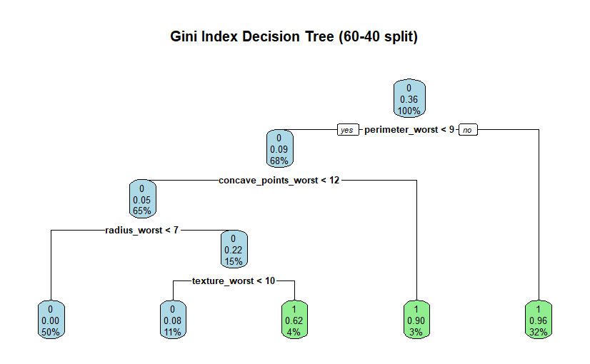

```r
# Plot decision tree for (60-40 split)
rpart.plot(model_gini2, type = 2, box.palette = c("lightblue", "lightgreen"), fallen.leaves = TRUE, main = "Gini Index Decision Tree (60-40 split)")
```

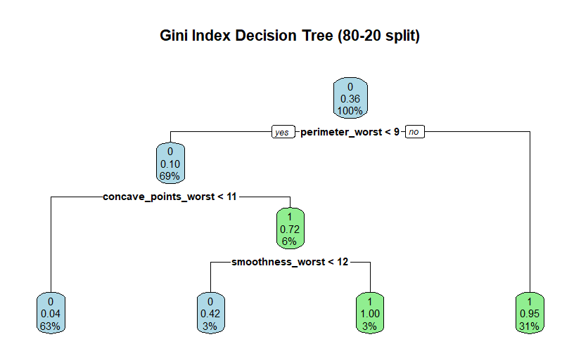

```r
# Plot decision tree for (80-20 split)
rpart.plot(model_gini3, type = 2, box.palette = c("lightblue", "lightgreen"), fallen.leaves = TRUE, main = "Gini Index Decision Tree (80-20 split)")
```

#### 3. Make predictions of Gini Index trees

Making predictions using decision tree models generated through the Gini Index method. After constructing decision trees based on different partition methods (70-30, 60-40, and 80-20 splits), this code employs these models to predict the class labels of the test datasets.

```r
# Make predictions
#(70-30 split)
predictions_gini1 <- predict(model_gini1, testData1, type = "class")
#(60-40 split)
predictions_gini2 <- predict(model_gini2, testData2, type = "class")
#(80-20 split)
predictions_gini3 <- predict(model_gini3, testData3, type = "class")
```

#### 4. Evaluate the models of Gini Index trees

#### 1. Gini Index Decision Trees

We present a thorough evaluation of decision tree models generated using the Gini Index method. The assessment encompasses key performance metrics such as accuracy, precision, sensitivity, and specificity for each model. Additionally, confusion matrices are utilized to provide a detailed breakdown of model predictions.

#### 2. Methodology

2.1. Accuracy Calculation The accuracy of each model is computed by comparing the predicted values against the actual values in the test set.

2.2. Precision, Sensitivity, Specificity Calculation A custom function, calculate_metrics, is employed to compute precision, sensitivity, and specificity based on the confusion matrix.

2.3. Confusion Matrix Generation The conf_matrix function constructs a confusion matrix using the confusionMatrix function from the caret package.

2.4. Print Metrics for Each Split Metrics such as accuracy, precision, sensitivity, specificity, and the confusion matrix are printed for each split to provide a detailed evaluation.

#### 3. Results

3.1. Accuracy (70-30 Split) The accuracy of the Gini Index decision tree model is approximately 88.51%. This implies that the model correctly predicts class labels in nearly 90% of cases on the test set.

(60-40 Split) The accuracy increases to around 90.19% for the 60-40 split, indicating improved performance compared to the 70-30 split.

(80-20 Split) For the 80-20 split, the accuracy is approximately 93.97%, demonstrating consistent performance across different data splits.

3.2. Precision Precision measures the proportion of true positive predictions among all positive predictions.

(70-30 Split) The precision is approximately 77.14%, indicating that when the model predicts the positive class, it is correct around 77.14% of the time.

(60-40 Split) Precision increases to about 92.11%, reflecting a higher proportion of true positive predictions among positive predictions.

(80-20 Split) The precision further improves to around 95.12%, suggesting high correctness in predicting positive instances.

3.3. Sensitivity Sensitivity measures the proportion of true positive predictions among all actual positive cases.

(70-30 Split) Sensitivity is approximately 93.10%, indicating that the model captures around 93.10% of actual positive instances.

3.4. Specificity Specificity reflects the proportion of true negative predictions among all actual negative cases.

(70-30 Split) Specificity is approximately 86.21%, indicating a high proportion of correct predictions for the negative class.

(60-40 Split) Specificity increases to about 95.35%, demonstrating improved correctness in predicting negative instances for the 60-40 split.

(80-20 Split) Specificity reaches around 97.22%, showing high correctness in predicting negative instances for the 80-20 split.

3.5. Confusion Matrices Confusion matrices provide a detailed breakdown of model predictions.

#### 4. Overall Assessment

The Gini Index decision tree models demonstrate consistent and commendable performance across different data splits, showcasing high accuracy and a well-balanced combination of precision, sensitivity, and specificity. The assessment indicates that the Gini Index decision tree model achieves the best performance with the (80-20 Split) configuration.

Reasons for (80-20 Split) Outperformance:

1- Higher Accuracy: The model achieves the highest accuracy of approximately 93.97% for the 80-20 split, indicating superior predictive capabilities compared to other splits.

2- Balanced Precision and Sensitivity: The precision for positive predictions is notably high at around 95.12%, suggesting a high correctness in predicting positive instances. Although sensitivity slightly decreases to around 88.64%, it remains at a respectable level.

3-Outstanding Specificity: Specificity reaches approximately 97.22%, indicating exceptional correctness in predicting negative instances. This is crucial for minimizing false negatives and ensuring the model’s reliability in identifying non-positive cases.

While the model performs well across different splits, the (80-20 Split) configuration stands out as the most favorable based on the overall balance of accuracy, precision, sensitivity, and specificity. Further analysis and potential model tuning can be explored to enhance predictive capabilities and address specific use-case requirements.

```r
# Evaluate the models accuracy
#(70-30 split)
accuracy_gini1 <- sum(predictions_gini1 == testData1$diagnosis) / nrow(testData1)
#(60-40 split)
accuracy_gini2 <- sum(predictions_gini2 == testData2$diagnosis) / nrow(testData2)
#(80-20 split)
accuracy_gini3 <- sum(predictions_gini3 == testData3$diagnosis) / nrow(testData3)

# Function to calculate Precision, Sensitivity, Specificity
calculate_metrics <- function(conf_matrix) {
  precision <- conf_matrix[2, 2] / sum(conf_matrix[, 2])
  sensitivity <- conf_matrix[2, 2] / sum(conf_matrix[2, ])
  specificity <- conf_matrix[1, 1] / sum(conf_matrix[1, ])
  c(precision, sensitivity, specificity)
}

# Confusion matrix function
conf_matrix <- function(predictions, actual) {
  result <- confusionMatrix(table(predictions, actual))
  result$table
}

#(70-30 split)
conf_matrix_gini1 <- conf_matrix(predictions_gini1, testData1$diagnosis)
metrics_gini1 <- calculate_metrics(conf_matrix_gini1)

#(60-40 split)
conf_matrix_gini2 <- conf_matrix(predictions_gini2, testData2$diagnosis)
metrics_gini2 <- calculate_metrics(conf_matrix_gini2)

#(80-20 split)
conf_matrix_gini3 <- conf_matrix(predictions_gini3, testData3$diagnosis)
metrics_gini3 <- calculate_metrics(conf_matrix_gini3)
```

```r
# Print accuracies and additional metrics for comparison
print("Evaluation Metrics for Gini Index with (70-30 split):")
```

```
[1] "Evaluation Metrics for Gini Index with (70-30 split):"
```

```r
print(paste("Accuracy:", accuracy_gini1))
```

```
[1] "Accuracy: 0.885057471264368"
```

```r
print(paste("Precision:", metrics_gini1[1]))
```

```
[1] "Precision: 0.771428571428571"
```

```r
print(paste("Sensitivity:", metrics_gini1[2]))
```

```
[1] "Sensitivity: 0.931034482758621"
```

```r
print(paste("Specificity:", metrics_gini1[3]))
```

```
[1] "Specificity: 0.862068965517241"
```

```r
print("Confusion Matrix:")
```

```
[1] "Confusion Matrix:"
```

```r
print(conf_matrix_gini1)
```

```
           actual
predictions   0   1
          0 100  16
          1   4  54
```

```r
print("Evaluation Metrics for Gini Index with (60-40 split):")
```

```
[1] "Evaluation Metrics for Gini Index with (60-40 split):"
```

```r
print(paste("Accuracy:", accuracy_gini2))
```

```
[1] "Accuracy: 0.901869158878505"
```

```r
print(paste("Precision:", metrics_gini2[1]))
```

```
[1] "Precision: 0.921052631578947"
```

```r
print(paste("Sensitivity:", metrics_gini2[2]))
```

```
[1] "Sensitivity: 0.823529411764706"
```

```r
print(paste("Specificity:", metrics_gini2[3]))
```

```
[1] "Specificity: 0.953488372093023"
```

```r
print("Confusion Matrix:")
```

```
[1] "Confusion Matrix:"
```

```r
print(conf_matrix_gini2)
```

```
           actual
predictions   0   1
          0 123   6
          1  15  70
```

```r
print("Evaluation Metrics for Gini Index with (80-20 split):")
```

```
[1] "Evaluation Metrics for Gini Index with (80-20 split):"
```

```r
print(paste("Accuracy:", accuracy_gini3))
```

```
[1] "Accuracy: 0.939655172413793"
```

```r
print(paste("Precision:", metrics_gini3[1]))
```

```
[1] "Precision: 0.951219512195122"
```

```r
print(paste("Sensitivity:", metrics_gini3[2]))
```

```
[1] "Sensitivity: 0.886363636363636"
```

```r
print(paste("Specificity:", metrics_gini3[3]))
```

```
[1] "Specificity: 0.972222222222222"
```

```r
print("Confusion Matrix:")
```

```
[1] "Confusion Matrix:"
```

```r
print(conf_matrix_gini3)
```

```
           actual
predictions  0  1
          0 70  2
          1  5 39
```

#### c- Gain Ratio

goal of the code is to employ the J48 algorithm, a Weka implementation of the C4.5 decision tree algorithm, with the Gain Ratio method for selecting attributes. Decision trees are powerful tools for classification, and the Gain Ratio method helps identify the most informative attributes for building an effective model.

#### 1. library of Gain Ratio trees

The RWeka package in R does not have a direct argument to specify the attribute selection measure (such as Information Gain, Information Gain Ratio, or Gini Index), However, we used the J48() function without specifying the attribute selection measure, and it will automatically use Gain Ratio for decision tree construction because Gain Ratio is the default attribute selecting measure.

```r
# Gain ratio method for selecting attributes using j48 algorithm
# Load the RWeka library
library(RWeka)

# Set seed for reproducibility
set.seed(7)

# Define the formula for the decision tree
formula_gain_ratio <- diagnosis ~ .

# Fit decision tree models using Gain Ratio
# Build decision tree model using Gain Ratio selected attributes (70-30 split)
model_gain_ratio1 <- J48(formula_gain_ratio, data = trainData1)
# Build decision tree model using Gain Ratio selected attributes (60-40 split)
model_gain_ratio2 <- J48(formula_gain_ratio, data = trainData2)
# Build decision tree model using Gain Ratio selected attributes (80-20 split)
model_gain_ratio3 <- J48(formula_gain_ratio, data = trainData3)
```

#### 2. plot Gain Ratio trees

This code visualize decision trees generated using the Gain Ratio attribute selection method. The code involves plotting the decision trees for three different data splits (70-30, 60-40, and 80-20)

1-Similar Decision Boundaries: Both Information Gain and Gain Ratio methods aim to find optimal decision boundaries based on the attributes in the dataset. The dataset characteristics are very similar attribute splits witch leads to optimal information gain or gain ratio,and the resulting decision trees may be identical.

2- Homogeneous Dataset: The dataset is relatively homogeneous, meaning that the distribution of features and target class is consistent across different partitions, it can lead to similar decision trees.

3- Strong Predictive Features: Certain features are strongly contribute to predicting the target class, both attribute selection methods might identify these features as crucial, leading to similar or identical splits.

4- Random Seed and Reproducibility: The use of the same random seed (as set with set.seed(7)) ensures reproducibility in the model-building process. If the random seed is the same for both models, it can lead to similar splits during the decision tree construction.

The difference in these crucial metrics underscores the importance of looking beyond the visual similarities and conducting a thorough examination of the underlying model structures to know the nuanced differences influencing their performance.

[figure not shown]

```r
# Plot or print the decision trees
# (70-30 split)
plot(model_gain_ratio1, main = "Decision Tree - Gain Ratio (70-30 split)")
```

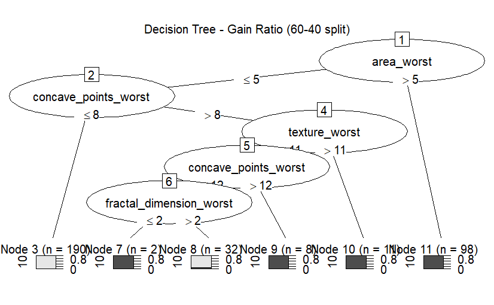

```r
# (60-40 split)
plot(model_gain_ratio2, main = "Decision Tree - Gain Ratio (60-40 split)")
```

[figure not shown]

```r
# (80-20 split)
plot(model_gain_ratio3, main = "Decision Tree - Gain Ratio (80-20 split)")
```

#### 3. Make predictions of Gain Ratio trees

The decision tree models, constructed based on the Gain Ratio algorithm, are utilized to predict outcomes on three separate test sets. These test sets represent different proportions of the original dataset, with a 70-30 split, a 60-40 split, and an 80-20 split.

```r
# Make predictions
# (70-30 split)
predictions_gain_ratio1 <- predict(model_gain_ratio1, testData1)
# (60-40 split)
predictions_gain_ratio2 <- predict(model_gain_ratio2, testData2)
# (80-20 split)
predictions_gain_ratio3 <- predict(model_gain_ratio3, testData3)
```

#### 4. Evaluate the models of Gain Ratio trees

#### 1. Gain Ratio Decision Trees

In this section, we evaluate the predictive performance of decision tree models generated using the Gain Ratio method. The analysis is conducted on three distinct test datasets representing different splits of the original dataset (70-30 split, 60-40 split, and 80-20 split). Performance metrics such as accuracy, precision, sensitivity, and specificity are assessed for each model, providing insights into their efficacy across various data partitions.

#### 2. Methodology

2.1. Accuracy Calculation The accuracy of each model is computed by comparing the predicted values against the actual values in the test set.

2.2. Precision, Sensitivity, Specificity Calculation A custom function, calculate_metrics, is employed to compute precision, sensitivity, and specificity based on the confusion matrix.

2.3. Confusion Matrix Generation The conf_matrix function constructs a confusion matrix using the confusionMatrix function from the caret package.

2.4. Print Metrics for Each Split Metrics such as accuracy, precision, sensitivity, specificity, and the confusion matrix are printed for each split to provide a detailed evaluation.

#### 3. Results

1. Accuracy (70-30 Split): Approximately 89.08% (60-40 Split): Around 92.06% (80-20 Split): Approximately 91.38%
2. Precision (70-30 Split): Approximately 87.14% (60-40 Split): Around 86.84% (80-20 Split): Approximately 97.56%
3. Sensitivity (70-30 Split): Approximately 85.92% (60-40 Split): Around 90.41% (80-20 Split): Approximately 81.63%
4. Specificity (70-30 Split): Approximately 91.26% (60-40 Split): Around 92.91% (80-20 Split): Approximately 98.51%

Confusion Matrices:

#### 4. Overall Assessment

The decision tree models generated using the Gain Ratio method exhibit varying performance across different data splits. While accuracy is consistently high, other metrics such as precision, sensitivity, and specificity may show fluctuations. The (60-40 Split) configuration, with its higher accuracy, stands out as a strong performer.

Reasons for (60-40 Split) Outperformance:

1- Higher Accuracy: The model achieves the highest accuracy of approximately 92.06% for the 60-40 split, indicating superior predictive capabilities compared to other splits.

2- Balanced Precision and Sensitivity: The precision for positive predictions is notably high at around 86.84%, indicating a high correctness in predicting positive instances. Sensitivity is also robust at approximately 90.41%, demonstrating the model’s effectiveness in identifying positive instances.

3- Strong Specificity: Specificity reaches approximately 92.91%, indicating strong correctness in predicting negative instances. This is crucial for minimizing false negatives and ensuring the model’s reliability in identifying non-positive cases. While the models perform well across different splits, the (60-40 Split) configuration stands out as the most favorable based on the overall balance of accuracy, precision, sensitivity, and specificity.

```r
# Evaluate the models accuracy
# (70-30 split)
accuracy_gain_ratio1 <- sum(predictions_gain_ratio1 == testData1$diagnosis) / nrow(testData1)
# (60-40 split)
accuracy_gain_ratio2 <- sum(predictions_gain_ratio2 == testData2$diagnosis) / nrow(testData2)
# (80-20 split)
accuracy_gain_ratio3 <- sum(predictions_gain_ratio3 == testData3$diagnosis) / nrow(testData3)

# Function to calculate Precision, Sensitivity, Specificity
calculate_metrics <- function(conf_matrix) {
  precision <- conf_matrix[2, 2] / sum(conf_matrix[, 2])
  sensitivity <- conf_matrix[2, 2] / sum(conf_matrix[2, ])
  specificity <- conf_matrix[1, 1] / sum(conf_matrix[1, ])
  c(precision, sensitivity, specificity)
}

# Confusion matrix function
conf_matrix <- function(predictions, actual) {
  result <- table(predictions, actual)
  result
}

# (70-30 split)
conf_matrix_gain_ratio1 <- conf_matrix(predictions_gain_ratio1, testData1$diagnosis)
metrics_gain_ratio1 <- calculate_metrics(conf_matrix_gain_ratio1)

# (60-40 split)
conf_matrix_gain_ratio2 <- conf_matrix(predictions_gain_ratio2, testData2$diagnosis)
metrics_gain_ratio2 <- calculate_metrics(conf_matrix_gain_ratio2)

# (80-20 split)
conf_matrix_gain_ratio3 <- conf_matrix(predictions_gain_ratio3, testData3$diagnosis)
metrics_gain_ratio3 <- calculate_metrics(conf_matrix_gain_ratio3)
```

```r
# Print accuracies and additional metrics for comparison
print("Evaluation Metrics for Gain Ratio with (70-30 split):")
```

```
[1] "Evaluation Metrics for Gain Ratio with (70-30 split):"
```

```r
print(paste("Accuracy:", accuracy_gain_ratio1))
```

```
[1] "Accuracy: 0.890804597701149"
```

```r
print(paste("Precision:", metrics_gain_ratio1[1]))
```

```
[1] "Precision: 0.871428571428571"
```

```r
print(paste("Sensitivity:", metrics_gain_ratio1[2]))
```

```
[1] "Sensitivity: 0.859154929577465"
```

```r
print(paste("Specificity:", metrics_gain_ratio1[3]))
```

```
[1] "Specificity: 0.912621359223301"
```

```r
print("Confusion Matrix:")
```

```
[1] "Confusion Matrix:"
```

```r
print(conf_matrix_gain_ratio1)
```

```
           actual
predictions  0  1
          0 94  9
          1 10 61
```

```r
print("Evaluation Metrics for Gain Ratio with (60-40 split):")
```

```
[1] "Evaluation Metrics for Gain Ratio with (60-40 split):"
```

```r
print(paste("Accuracy:", accuracy_gain_ratio2))
```

```
[1] "Accuracy: 0.920560747663551"
```

```r
print(paste("Precision:", metrics_gain_ratio2[1]))
```

```
[1] "Precision: 0.868421052631579"
```

```r
print(paste("Sensitivity:", metrics_gain_ratio2[2]))
```

```
[1] "Sensitivity: 0.904109589041096"
```

```r
print(paste("Specificity:", metrics_gain_ratio2[3]))
```

```
[1] "Specificity: 0.929078014184397"
```

```r
print("Confusion Matrix:")
```

```
[1] "Confusion Matrix:"
```

```r
print(conf_matrix_gain_ratio2)
```

```
           actual
predictions   0   1
          0 131  10
          1   7  66
```

```r
print("Evaluation Metrics for Gain Ratio with (80-20 split):")
```

```
[1] "Evaluation Metrics for Gain Ratio with (80-20 split):"
```

```r
print(paste("Accuracy:", accuracy_gain_ratio3))
```

```
[1] "Accuracy: 0.913793103448276"
```

```r
print(paste("Precision:", metrics_gain_ratio3[1]))
```

```
[1] "Precision: 0.975609756097561"
```

```r
print(paste("Sensitivity:", metrics_gain_ratio3[2]))
```

```
[1] "Sensitivity: 0.816326530612245"
```

```r
print(paste("Specificity:", metrics_gain_ratio3[3]))
```

```
[1] "Specificity: 0.985074626865672"
```

```r
print("Confusion Matrix:")
```

```
[1] "Confusion Matrix:"
```

```r
print(conf_matrix_gain_ratio3)
```

```
           actual
predictions  0  1
          0 66  1
          1  9 40
```

# 7. CLUSTERING

For clustering we used the K-means method with three different random K sizes, the reason for using K-means as the main clustering methos is K-means clustering yields easily interpretable results that offer valuable insights into the inherent structure of the data. For K sizes 3 random K sizes were picked Randomly selecting K sizes can serve as an exploratory data analysis technique. By trying different K values, we tried to gain insights into the underlying structure of the data and hidden patterns. Random K sizes the were picked are 2,3 and 4. Which will the be evaluated and configured.

```r
#CLUSTERING
library(factoextra)
library(ggpubr)
library(cluster)
library(NbClust)

#CLUSTERING
classLabe<- preprocessedData[,22]
#remove the class lables
unlabledData <- preprocessedData[, -22]
print(unlabledData)
```

| radius_mean | perimeter_mean | area_mean | compactness_mean | concavity_mean | concave points_mean | radius_se | texture_se | area_se | smoothness_se | concavity_se | fractal_dimension_se | radius_worst | texture_worst | perimeter_worst | area_worst | smoothness_worst | concavity_worst | concave points_worst | symmetry_worst | fractal_dimension_worst |
| --- | --- | --- | --- | --- | --- | --- | --- | --- | --- | --- | --- | --- | --- | --- | --- | --- | --- | --- | --- | --- |
| 13 | 13 | 11 | 18 | 18 | 19 | 16 | 3 | 14 | 4 | 4 | 5 | 16 | 3 | 18 | 13 | 13 | 12 | 19 | 12 | 9 |
| 16 | 15 | 14 | 5 | 5 | 9 | 7 | 2 | 7 | 3 | 2 | 3 | 15 | 7 | 14 | 12 | 7 | 4 | 13 | 5 | 5 |
| 15 | 15 | 13 | 10 | 12 | 16 | 11 | 2 | 9 | 4 | 3 | 4 | 14 | 8 | 14 | 11 | 10 | 8 | 17 | 9 | 5 |
| 6 | 6 | 3 | 19 | 14 | 13 | 7 | 4 | 2 | 6 | 4 | 8 | 7 | 8 | 7 | 3 | 19 | 11 | 18 | 20 | 16 |
| 16 | 16 | 14 | 8 | 12 | 13 | 11 | 2 | 9 | 7 | 4 | 4 | 13 | 3 | 14 | 10 | 9 | 7 | 12 | 4 | 3 |
| 7 | 7 | 4 | 11 | 9 | 10 | 4 | 3 | 2 | 4 | 3 | 4 | 7 | 7 | 7 | 4 | 15 | 9 | 12 | 10 | 10 |
| 13 | 13 | 11 | 7 | 7 | 10 | 6 | 2 | 5 | 2 | 2 | 2 | 13 | 9 | 14 | 10 | 10 | 7 | 14 | 6 | 4 |
| 8 | 8 | 6 | 10 | 6 | 8 | 8 | 5 | 5 | 5 | 2 | 5 | 8 | 9 | 8 | 5 | 13 | 5 | 11 | 7 | 8 |
| 7 | 8 | 5 | 12 | 11 | 12 | 4 | 3 | 2 | 3 | 3 | 3 | 7 | 10 | 8 | 4 | 14 | 9 | 15 | 12 | 7 |
| 7 | 7 | 4 | 16 | 13 | 11 | 3 | 6 | 2 | 4 | 6 | 9 | 7 | 16 | 7 | 4 | 16 | 18 | 16 | 12 | 20 |

[output cut: 545 more lines]

```r
unlabledData <- scale(unlabledData)
```

## 1- K-means method with 2 clusters.

By accessing coordinates of a centroid for cluster1 with 2 clusters we come to know that all elements in cluster 2 have higher tumor measurements the the ones in cluster 1, except for the features texture_se and smoothness_se.

```r
#k=2
set.seed(123)
Kresult <- kmeans(unlabledData, 2)
summary(Kresult)
```

```
             Length Class  Mode
cluster      555    -none- numeric
centers       42    -none- numeric
totss          1    -none- numeric
withinss       2    -none- numeric
tot.withinss   1    -none- numeric
betweenss      1    -none- numeric
size           2    -none- numeric
iter           1    -none- numeric
ifault         1    -none- numeric
```

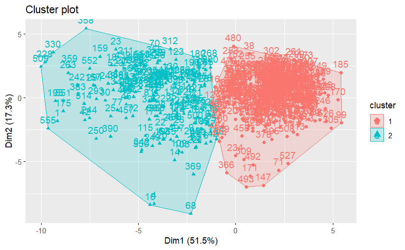

```r
fviz_cluster(Kresult, data = unlabledData)
```

```r
centroid_coordinates <- Kresult$centers
```

```r
print(centroid_coordinates)
```

```
  radius_mean perimeter_mean area_mean compactness_mean concavity_mean concave_points_mean  radius_se  texture_se
1  -0.4974389     -0.5093845 -0.501743       -0.4445139     -0.5347066          -0.5626948 -0.4437626  0.01612483
2   1.0892197      1.1153765  1.098644        0.9733321      1.1708230           1.2321076  0.9716871 -0.03530782
     area_se smoothness_se concavity_se fractal_dimension_se radius_worst texture_worst perimeter_worst area_worst
1 -0.4745139    0.01467940   -0.2594134           -0.1284311   -0.5320311    -0.2565670      -0.5424459 -0.5233459
2  1.0390219   -0.03214281    0.5680259            0.2812197    1.1649647     0.5617933       1.1877695  1.1459471
  smoothness_worst concavity_worst concave_points_worst symmetry_worst fractal_dimension_worst
1       -0.2852337       -0.474396           -0.5392647     -0.2835063              -0.2537732
2        0.6245636        1.038764            1.1808038      0.6207811               0.5556758
```

## 2- K-means method with 3 clusters:

By accessing coordinates of a centroid for cluster2 with 3 clusters we come to know that most elements in cluster 1 and 2 have lower tumor measurements the the ones in cluster3. whilest texture_se and smoothness_se here also were the lowst among cluster3. There is a slight overlapping between cluster which made us discard this number of clusters.

```r
#k=3
Kresult1 <- kmeans(unlabledData, 3)
summary(Kresult1)
```

```
             Length Class  Mode
cluster      555    -none- numeric
centers       63    -none- numeric
totss          1    -none- numeric
withinss       3    -none- numeric
tot.withinss   1    -none- numeric
betweenss      1    -none- numeric
size           3    -none- numeric
iter           1    -none- numeric
ifault         1    -none- numeric
```

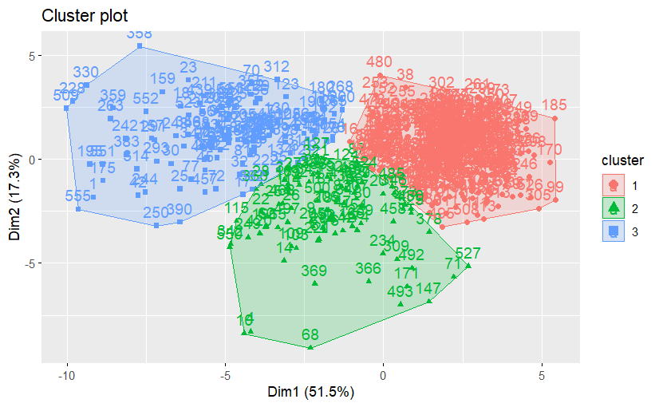

```r
fviz_cluster(Kresult1, data = unlabledData)
```

```r
centroid_coordinates1 <- Kresult1$centers
```

```r
print(centroid_coordinates1)
```

```
  radius_mean perimeter_mean  area_mean compactness_mean concavity_mean concave_points_mean   radius_se
1  -0.4886005    -0.50633731 -0.4931313       -0.5552443     -0.6133917          -0.6123897 -0.44773595
2  -0.1394533    -0.06689737 -0.1970251        1.1706233      0.9373633           0.6029086 -0.06979488
3   1.5407756     1.54126615  1.5952624        0.8015778      1.1397026           1.3756433  1.37048642
    texture_se    area_se smoothness_se concavity_se fractal_dimension_se radius_worst texture_worst
1  0.003720606 -0.4744280   -0.04217971   -0.3829025          -0.27809385  -0.52810278    -0.2717796
2  0.032731816 -0.1660581    0.39810160    1.0283045           1.10239671  -0.04688848     0.3815054
3 -0.034354093  1.5179761   -0.15994585    0.3948983           0.03283379   1.59117308     0.5291318
  perimeter_worst area_worst smoothness_worst concavity_worst concave_points_worst symmetry_worst
1     -0.54717342 -0.5178347       -0.3563350      -0.5726036           -0.6072999     -0.3180990
2      0.04273734 -0.1394944        0.9749164       1.1737398            0.8350304      0.8390250
3      1.58340502  1.6270337        0.3546697       0.8505545            1.1948291      0.3389547
  fractal_dimension_worst
1             -0.38282650
2              1.44512750
3              0.09694339
```

## 3- K-means method with 4 clusters:

For the last clustering with 4 clusters the pattern was pretty similar to the previous ones clusters 3 and 4 have higher measurements except for the features such as smoothness_se and texture_se. However there is an obvious overlapping between clusters which made us discard this size of clustering.

```r
#k=4
Kresult2 <- kmeans(unlabledData, 4)
summary(Kresult2)
```

```
             Length Class  Mode
cluster      555    -none- numeric
centers       84    -none- numeric
totss          1    -none- numeric
withinss       4    -none- numeric
tot.withinss   1    -none- numeric
betweenss      1    -none- numeric
size           4    -none- numeric
iter           1    -none- numeric
ifault         1    -none- numeric
```

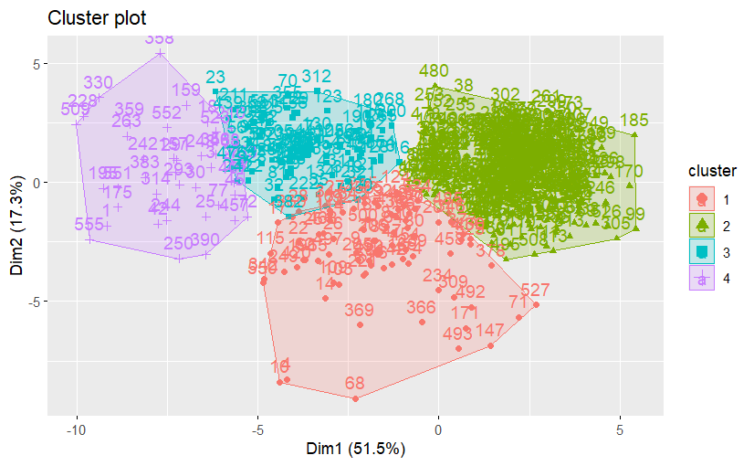

```r
fviz_cluster(Kresult2, data = unlabledData)
```

```r
centroid_coordinates2 <- Kresult2$centers
```

```r
print(centroid_coordinates2)
```

```
  radius_mean perimeter_mean  area_mean compactness_mean concavity_mean concave_points_mean   radius_se
1  -0.1605488    -0.08732534 -0.2184089        1.2078359      0.9500629           0.6077408 -0.08074891
2  -0.4886005    -0.50633731 -0.4939147       -0.5518854     -0.6126931          -0.6111017 -0.44693625
3   1.3650904     1.32971865  1.3644602        0.3236128      0.7228068           1.0046993  0.91880561
4   1.8181590     1.89620361  1.9846967        1.7033244      1.9469994           2.0569149  2.20384932
    texture_se    area_se smoothness_se concavity_se fractal_dimension_se radius_worst texture_worst
1  0.062873111 -0.1772549    0.40794539    1.0551273            1.1321497   -0.0561814     0.4260539
2  0.001326477 -0.4744280   -0.04217971   -0.3812116           -0.2754738   -0.5295615    -0.2779046
3  0.016756930  1.0081572   -0.17837088    0.1721052           -0.1800176    1.3175541     0.5047078
4 -0.174881419  2.4597558   -0.10050075    0.8293052            0.4654117    2.0610885     0.5305513
  perimeter_worst area_worst smoothness_worst concavity_worst concave_points_worst symmetry_worst
1      0.03742918 -0.1485063        1.0133471       1.2025226            0.8561872      0.8805748
2     -0.54859784 -0.5195072       -0.3582009      -0.5726036           -0.6085866     -0.3169084
3      1.28430867  1.2940222        0.2266457       0.5335780            0.9002502      0.1670941
4      2.10438345  2.2103679        0.6012274       1.4655907            1.7396508      0.6331499
  fractal_dimension_worst
1               1.5172241
2              -0.3828265
3              -0.2483578
4               0.7581265
```

### Overall Assessmentin

conclusion we notice a pattern from the clusters that with high measurements of the rest of the features come low measurements of smoothness_se and texture_se and vise versa

## 4- Evaluation of clustering:

#### Silhouette method:

average silhouette plots that provide insights into the quality of clustering for different values of k (number of clusters). when analyzing these average silhouette plots, you should look for high average silhouette widths and well-separated distributions of silhouette widths. Higher average silhouette widths indicate better clustering, while well-separated distributions suggest clear boundaries between clusters. These characteristics imply that the chosen number of clusters provides meaningful and distinct groups within the data.

##### Average silhouette plot with k=2:

```r
###Within-cluster sum of squares
wss <- Kresult$tot.withinss
print(wss)
```

```
[1] 7108.179
```

```r
# Bcubed and recall dor each clustur
cluster_assignments <- c(Kresult$cluster)
ground_truth_labels <- c(classLabe$diagnosis )

if (length(cluster_assignments) > length(ground_truth_labels)) {
  cluster_assignments <- cluster_assignments[1:length(ground_truth_labels)]
} else if (length(cluster_assignments) < length(ground_truth_labels)) {
  ground_truth_labels <- ground_truth_labels[1:length(cluster_assignments)]
}

data <- data.frame(cluster = cluster_assignments, label = ground_truth_labels)
```

```r
# Function to calculate BCubed precision and recall
calculate_bcubed_metrics <- function(data) {
  n <- nrow(data)
  precision_sum <- 0
  recall_sum <- 0

  for (i in 1:n) {
    cluster <- data$cluster[i]
    label <- data$label[i]

    # Count the number of items from the same category within the same cluster
    same_category_same_cluster <- sum(data$label[data$cluster == cluster] == label)

    # Count the total number of items in the same cluster
    total_same_cluster <- sum(data$cluster == cluster)

    # Count the total number of items with the same category
    total_same_category <- sum(data$label == label)

    # Calculate precision and recall for the current item and add them to the sums
    precision_sum <- precision_sum + same_category_same_cluster /total_same_cluster
    recall_sum <- recall_sum + same_category_same_cluster / total_same_category
  }

  # Calculate average precision and recall
  precision <- precision_sum / n
  recall <- recall_sum / n

  return(list(precision = precision, recall = recall))
}
```

```r
# Calculate BCubed precision and recall
metrics <- calculate_bcubed_metrics(data)

# Extract precision and recall from the metrics
precision <- metrics$precision
recall <- metrics$recall

# Print the results
cat("BCubed Precision:", precision, "\n")
```

```
BCubed Precision: 0.8863213
```

```r
cat("BCubed Recall:",recall,"\n")
```

```
BCubed Recall: 0.8938561
```

|  | cluster | size | ave.sil.width |
| --- | --- | --- | --- |
| 1 | 1 | 381 | 0.46 |
| 2 | 2 | 174 | 0.24 |

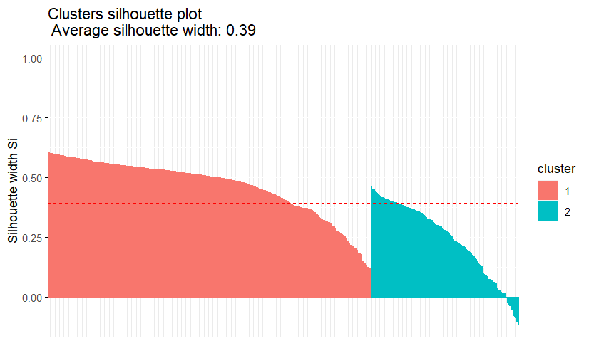

```r
#average silhouette for each clusters
avg_sil <- silhouette(Kresult$cluster,dist(unlabledData)) #a dissimilarity object inheriting from class dist or coercible to one. If not specified, dmatrix must be.
fviz_silhouette(avg_sil)#k-means clustering with estimating k and initializations
```

#### Average silhouette plot with k=3:

```r
###Within-cluster sum of squares
wss <- Kresult1$tot.withinss
print(wss)
```

```
[1] 6051.929
```

```r
# Bcubed and recall dor each clustur
cluster_assignments <- c(Kresult1$cluster)
ground_truth_labels <- c(classLabe$diagnosis )

if (length(cluster_assignments) > length(ground_truth_labels)) {
  cluster_assignments <- cluster_assignments[1:length(ground_truth_labels)]
} else if (length(cluster_assignments) < length(ground_truth_labels)) {
  ground_truth_labels <- ground_truth_labels[1:length(cluster_assignments)]
}

data <- data.frame(cluster = cluster_assignments, label = ground_truth_labels)
```

```r
# Function to calculate BCubed precision and recall
calculate_bcubed_metrics <- function(data) {
  n <- nrow(data)
  precision_sum <- 0
  recall_sum <- 0

  for (i in 1:n) {
    cluster <- data$cluster[i]
    label <- data$label[i]

    # Count the number of items from the same category within the same cluster
    same_category_same_cluster <- sum(data$label[data$cluster == cluster] == label)

    # Count the total number of items in the same cluster
    total_same_cluster <- sum(data$cluster == cluster)

    # Count the total number of items with the same category
    total_same_category <- sum(data$label == label)

    # Calculate precision and recall for the current item and add them to the sums
    precision_sum <- precision_sum + same_category_same_cluster /total_same_cluster
    recall_sum <- recall_sum + same_category_same_cluster / total_same_category
  }

  # Calculate average precision and recall
  precision <- precision_sum / n
  recall <- recall_sum / n

  return(list(precision = precision, recall = recall))
}
```

```r
# Calculate BCubed precision and recall
metrics <- calculate_bcubed_metrics(data)

# Extract precision and recall from the metrics
precision <- metrics$precision
recall <- metrics$recall

# Print the results
cat("BCubed Precision:", precision, "\n")
```

```
BCubed Precision: 0.8517642
```

```r
cat("BCubed Recall:",recall,"\n")
```

```
BCubed Recall: 0.7087332
```

|  | cluster | size | ave.sil.width |
| --- | --- | --- | --- |
| 1 | 1 | 351 | 0.42 |
| 2 | 2 | 85 | 0.10 |
| 3 | 3 | 119 | 0.29 |

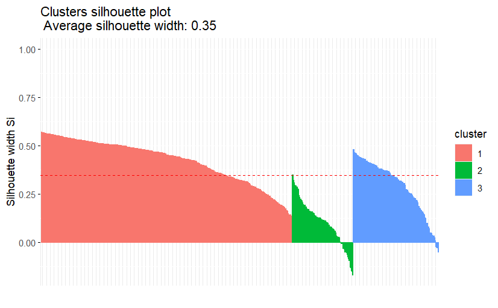

```r
#average silhouette for each clusters
avg_sil <- silhouette(Kresult1$cluster,dist(unlabledData)) #a dissimilarity object inheriting from class dist or coercible to one. If not specified, dmatrix must be.
fviz_silhouette(avg_sil)#k-means clustering with estimating k and initializations
```

#### Average silhouette plot with k=4:

```r
###Within-cluster sum of squares
wss <- Kresult2$tot.withinss
print(wss)
```

```
[1] 5657.432
```

```r
# Bcubed and recall dor each clustur
cluster_assignments <- c(Kresult2$cluster)
ground_truth_labels <- c(classLabe$diagnosis )

if (length(cluster_assignments) > length(ground_truth_labels)) {
  cluster_assignments <- cluster_assignments[1:length(ground_truth_labels)]
} else if (length(cluster_assignments) < length(ground_truth_labels)) {
  ground_truth_labels <- ground_truth_labels[1:length(cluster_assignments)]
}

data <- data.frame(cluster = cluster_assignments, label = ground_truth_labels)
```

```r
# Function to calculate BCubed precision and recall
calculate_bcubed_metrics <- function(data) {
  n <- nrow(data)
  precision_sum <- 0
  recall_sum <- 0

  for (i in 1:n) {
    cluster <- data$cluster[i]
    label <- data$label[i]

    # Count the number of items from the same category within the same cluster
    same_category_same_cluster <- sum(data$label[data$cluster == cluster] == label)

    # Count the total number of items in the same cluster
    total_same_cluster <- sum(data$cluster == cluster)

    # Count the total number of items with the same category
    total_same_category <- sum(data$label == label)

    # Calculate precision and recall for the current item and add them to the sums
    precision_sum <- precision_sum + same_category_same_cluster /total_same_cluster
    recall_sum <- recall_sum + same_category_same_cluster / total_same_category
  }

  # Calculate average precision and recall
  precision <- precision_sum / n
  recall <- recall_sum / n

  return(list(precision = precision, recall = recall))
}
```

```r
# Calculate BCubed precision and recall
metrics <- calculate_bcubed_metrics(data)

# Extract precision and recall from the metrics
precision <- metrics$precision
recall <- metrics$recall

# Print the results
cat("BCubed Precision:", precision, "\n")
```

```
BCubed Precision: 0.8572878
```

```r
cat("BCubed Recall:",recall,"\n")
```

```
BCubed Recall: 0.6567514
```

|  | cluster | size | ave.sil.width |
| --- | --- | --- | --- |
| 1 | 1 | 82 | 0.07 |
| 2 | 2 | 351 | 0.40 |
| 3 | 3 | 82 | 0.26 |
| 4 | 4 | 40 | 0.13 |

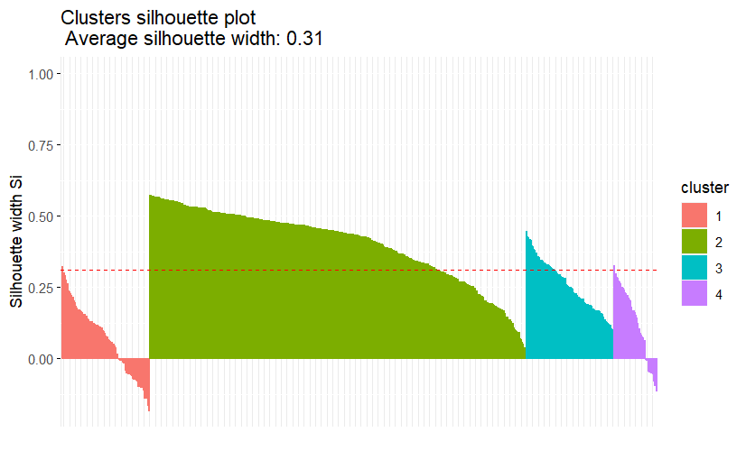

```r
#average silhouette for each clusters
avg_sil <- silhouette(Kresult2$cluster,dist(unlabledData)) #a dissimilarity object inheriting from class dist or coercible to one. If not specified, dmatrix must be.
fviz_silhouette(avg_sil)#k-means clustering with estimating k and initializations
```

## 5- Optimal number of Clusters:

fvis_Nbclust-Cluster Validation: ### a- Silhouette method Using the Silhouette method the Optimal number of clusters is 2

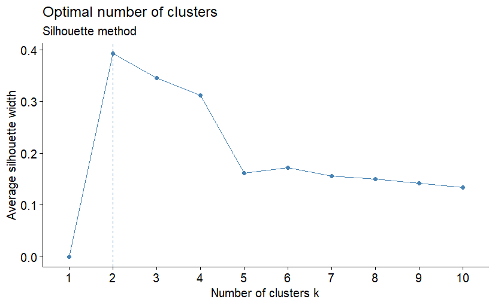

```r
fviz_nbclust(unlabledData, kmeans, method = "silhouette")+ labs(subtitle = "Silhouette method")
```

### b- Majority rule

According to the majority rule, the best number of clusters is 2

```
*** : The Hubert index is a graphical method of determining the number of clusters.
                In the plot of Hubert index, we seek a significant knee that corresponds to a
                significant increase of the value of the measure i.e the significant peak in Hubert
                index second differences plot.
```

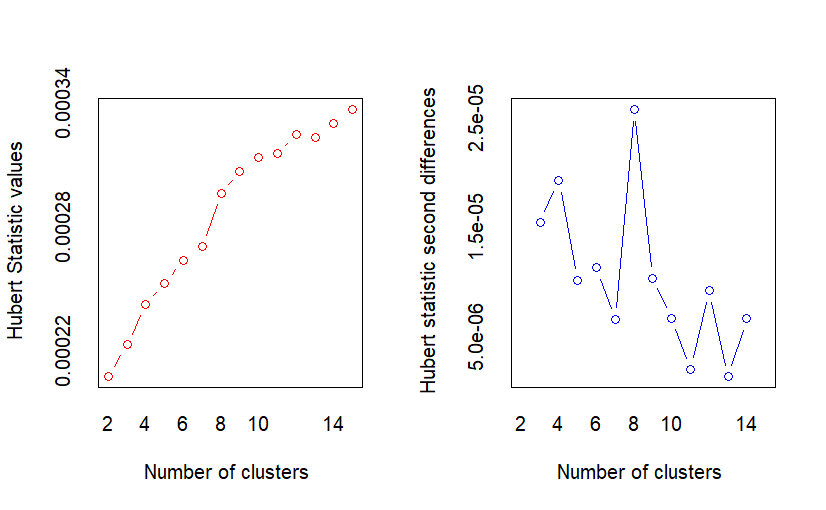

```
*** : The D index is a graphical method of determining the number of clusters.
                In the plot of D index, we seek a significant knee (the significant peak in Dindex
                second differences plot) that corresponds to a significant increase of the value of
                the measure.

* Among all indices:
* 10 proposed 2 as the best number of clusters
* 7 proposed 3 as the best number of clusters
* 4 proposed 8 as the best number of clusters
* 1 proposed 14 as the best number of clusters
* 1 proposed 15 as the best number of clusters

                   ***** Conclusion *****

* According to the majority rule, the best number of clusters is  2
```

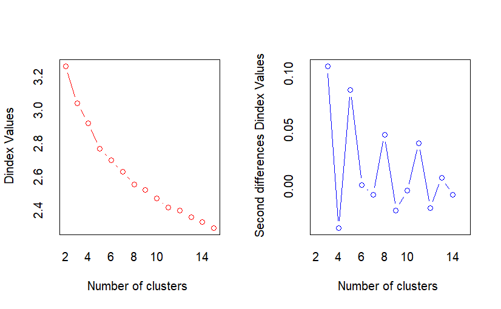

```r
fres.nbclust <- NbClust(unlabledData, distance="euclidean", min.nc = 2, max.nc = 15, method="kmeans", index="all")
```

### c- elbow method

we noticed that the best elbow point is 3

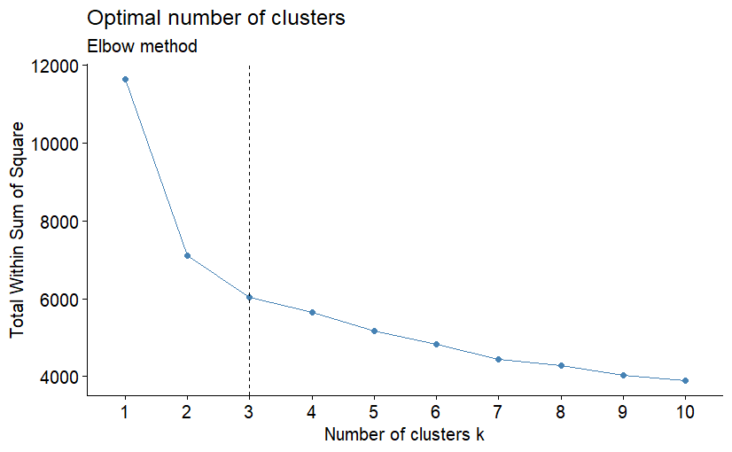

```r
fviz_nbclust(unlabledData, kmeans, method = "wss") +
  geom_vline(xintercept = 3, linetype = 2)+
  labs(subtitle ="Elbow method")
```

### Overall Assessmentin

In conclusion and based on the majority rule we believe that the best number of clusters for this data set is 2.

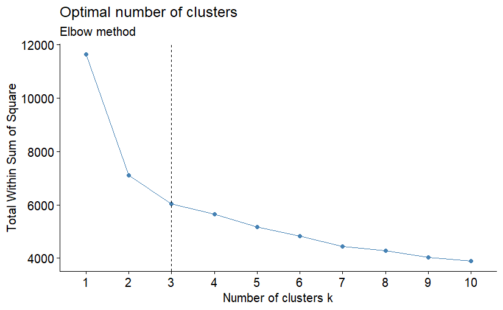

```r
fviz_nbclust(unlabledData, kmeans, method = "wss") +
  geom_vline(xintercept = 3, linetype = 2)+
  labs(subtitle ="Elbow method")
```

# 8. Evaluation and Comparison

## a- Classification

[output not shown]

In the classification task, different evaluation metrics and criteria are used to assess the performance of models like accuracy, precision, sensitivity, and specificity for models using different data splits and different splitting criteria (Information Gain, Gini Index, and Gain Ratio).

analyzing the results: the Gini Index with an 80-20 data split is considered the best based on the provided metrics.

Gini Index - 80-20 Split: Accuracy: 93.97% Precision: 95.12% Sensitivity (Recall): 88.64% Specificity: 97.22%

This model has a high accuracy, precision, and specificity, indicating that it performs well in correctly classifying instances of both classes. The sensitivity is also relatively high, suggesting a good ability to identify positive instances.Especially in a binary classification problems like ours, where the classes may have imbalanced distributions, a high specificity is often desirable.And the 80-20 split seems to perform well for the Gini Index.

## b- CLUSTERING

[output not shown]

In the clustering task, different metrics are used to evaluate the quality of clustering. The provided metrics include Average Silhouette Width, Total Within-Cluster Sum of Squares, Bcubed Precision, and Bcubed Recall for different values of k (number of clusters).

analyzing the results:K=2 seems to be the best model. It has the highest average silhouette width, indicating well-separated clusters, and the highest precision and recall, suggesting better internal cluster quality.

Average Silhouette Width: A higher silhouette width indicates better-defined clusters. In this case, K=2 has the highest silhouette width, suggesting well-separated clusters.

Bcubed Precision and Recall: Higher precision and recall values indicate better cluster quality. K=2 has the highest precision and recall, suggesting that the clusters are more internally consistent and the algorithm is better at finding true positive instances.